# Analyse multidimensionnelle de la précarité dans le système urbain français

Annexes avec code R commenté

# 1 Organisation du document & Chargement des données

Ce fichier d’annexes présente un code R commenté, suivant la chronologie de la chaîne de traitements ayant permis les analyses présentées dans l’article : [Paul Gourdon, Matthieu Delage, Julie Fromentin, Benoit Conti, Sophie Baudet-Michel et Laurent Terral, 2025, « Analyse multidimensionnelle de la précarité dans le système urbain français », *Cybergeo: European Journal of Geography*](https://journals.openedition.org/cybergeo/42415)

Ouverture de plusieurs tables :

- La table principale, donnée dérivée de trois sources accessibles *via* le CASD ([RP - INSEE](https://www.casd.eu/source/recensement-de-la-population/) ; [ALLSTAT_FR6 - CNAF](https://www.casd.eu/source/fichier-statistique-des-allocataires-des-caf-donnees-definitives/) ; [IRCOM - DGFIP](https://www.casd.eu/source/impot-sur-le-revenu-agrege-a-la-commune/)). L’individu statistique est l’Aire Urbaine (AU), les variables sont en stock et respectent les seuils de secret statistique propres à chaque source. Les valeurs masquées sont ramenées à 0 dans la suite des analyses.
- Une table d’informations identifiantes pour les AU avec un fichier de géométries (geojson)
- Un fichier de géométries pour les départements (habillage)
- Un dictionnaire de variables

Les données portent toutes sur **l’année 2018**.

```r
# packages
library(clv)
library(corrplot)
library(DescTools)
library(DT)
library(explor)
library(factoextra)
library(FactoMineR)
library(GGally)
library(ggcorrplot)
library(ggforce)
library(ggpmisc)
library(ggpp)
library(ggpubr)
library(ggrepel)
library(ggsci)
library(gplots)
library(kableExtra)
library(mcclust)
library(RColorBrewer)
library(reactable)
library(reactablefmtr)
library(readODS)
library(sf)
library(skimr)
library(tidyverse)
library(vcd)
library(labelled)


#### Pas d'écriture scientifique ##

options(scipen = 999)

## Données stocks pour les AU (sources : CASD)

df <- readRDS("../Data/au2018_casd.rds")

## Géométries agrégées des AU (pour la carto)

AUsf <- st_read("../Data/geom/AUsf.geojson", quiet = TRUE)


# Informations simples (ID) pour les AU : nom, département, région, etc.

au_info <- read.csv2("../Data/Au_Info.csv")

#  Geometries des departements (habillage)

depsf <- st_read("../Data/geom/a-dep2021.json", quiet = TRUE)

# Dictionnaire de variables

DicoVar <- read.csv2("../Data/VarIntens_ComputePrecarite.csv",
                     fileEncoding = "UTF-8")
```

# 2 Intensité de la précarité : quelles différenciations spatiales ?

Cette partie du script détaille le calcul de variables relatives permettant de saisir l’intensité de diverses formes de précarité dans la population des aires urbaines françaises.

Il s’agit principalement d’analyses univariées et bivariées visant une première appréhension des différenciations spatiales observables.

## 2.1 Calcul des variables et ordres de grandeurs

Les 8 variables relatives retenues pour les analyses dans l’article sont construites à partir des 13 variables de stock suivantes :

- `P18_POP_rp18` : population au recensement de la population de 2018 (Insee)
- `NB_Pers_couv_RSA` : nombre de personnes couvertes par le RSA en décembre 2018 (Cnaf)
- `ALL_AAH` : nombre de foyers allocataires de l’AAH (Allocation Adulte Handicapé) en décembre 2018 (Cnaf)
- `RP_NBFOY_TOTAL` : nombre de foyers fiscaux concernés par les retraites et pensions, données de 2019 sur l’année fiscale 2018 (Ircom)
- `TS_NBFOY_TOTAL` : nombre de foyers fiscaux concernés par les traitements et salaires, données de 2019 sur l’année fiscale 2018 (Ircom)
- `NFOYFISC_PAUVRE_RP` : nombre de foyers fiscaux retraités dont les retraites et pensions sont inférieures à 12 000 euros par an , données de 2019 sur l’année fiscale 2018 (Ircom)
- `NFOYFISC_PAUVRE_TS` : nombre de foyers fiscaux dont les traitements et salaires sont inférieurs à 12 000 euros par an, données de 2019 sur l’année fiscale 2018 (Ircom)
- `NCHOM15P_18` : nombre d’individus de 15 ans et plus eau chômage, au recensement de 2018 (Insee)
- `NACT_18` : nombre d’actifs, au recensement de 2018 (Insee)
- `NINTERIM15P_18` : nombre d’individus de 15 ans et plus en interim, au recensement de 2018 (Insee)
- `NCHOMLONG` : nombre d’individus au chômage en recherche d’emploi depuis un an ou plus, au recensement de 2018 (Insee)
- `NCHOMCOURT` :nombre d’individus au chômage en recherche d’emploi depuis moins d’un an, au recensement de 2018 (Insee)
- `NEMPL_INF_PEUQUAL_CDD` : nombre d’individus en emploi salarié d’exécution peu qualifié en contrat court, au recensement de 2018. Cette variable combine plusieurs modalités de la variable de position professionnelle (modalités “Manoeuvre, ouvrier spécialisé”, “Ouvrier qualifié ou hautement qualifié, technicien d’atelier”, “Employé”, “Agent de catégorie C de la fonction publique”) avec les conditions d’emploi (modalités “En contrat d’apprentissage ou de professionnalisation”, “Placé par une agence d’intérim”, “Emploi aidé (contrat unique d’insertion, d’initiative emploi, d’accompagnement dans l’emploi, avenir, etc.)”, “Stagiaire rémunéré en entreprise”, “Autre emploi à durée limitée, CDD, contrat court, saisonnier, vacataire…” ) dans l’exploitation principale du recensement de 2018 (Insee)

**Les 8 variables relatives utilisées dans l’article sont les suivantes**

- `RSA_1khab` : nombre de personnes couvertes par le RSA pour 1000 habitants
- `AAH_1khab` : nombre d’allocataires de l’AAH pour 1000 habitants
- `FOYFISC_PAUVRE_RP` : Part des foyers retraités pauvres (< 12 k euros/an) sur l’ensemble des foyers fiscaux concernés par les retraites et pensions
- `FOYFISC_PAUVRE_TS` : Part des foyers traitements et salaires pauvres (< 12 k euros/an) sur l’ensemble des foyers fiscaux concernés par les traitements et salaires - INTERIM : Part de l’interim dans l’ensemble des actifs
- `EMPL_INF_PEUQUAL_CDD` : Part des salariés d’exécution peu qualifiés en contrat court parmi l’ensemble des actifs
- `CHOM_LONG` : Part des chômeurs longue durée (>=1 an) parmi l’ensemble des actifs
- `CHOM_COURT` : Part des chômeurs courte durée (<1 an) parmi l’ensemble des actifs

```r
# vérification rapide du tableau du tableau (notamment pour les NA)

skim(df)
```

Data summary

| Name | df |
| --- | --- |
| Number of rows | 793 |
| Number of columns | 14 |
| _______________________ |  |
| Column type frequency: |  |
| character | 1 |
| numeric | 13 |
| ________________________ |  |
| Group variables | None |

**Variable type: character**

| skim_variable | n_missing | complete_rate | min | max | empty | n_unique | whitespace |
| --- | --- | --- | --- | --- | --- | --- | --- |
| AU2010 | 0 | 1 | 3 | 3 | 0 | 793 | 0 |

**Variable type: numeric**

| skim_variable | n_missing | complete_rate | mean | sd | p0 | p25 | p50 | p75 | p100 | hist |
| --- | --- | --- | --- | --- | --- | --- | --- | --- | --- | --- |
| P18_POP_rp18 | 0 | 1.00 | 84152.00 | 516142.52 | 0.00 | 5396.00 | 10476.00 | 34209.00 | 12667053.00 | ▇▁▁▁▁ |
| NB_Pers_couv_RSA | 0 | 1.00 | 4922.85 | 27241.96 | 24.00 | 236.00 | 555.00 | 2042.00 | 675381.00 | ▇▁▁▁▁ |
| ALL_AAH | 0 | 1.00 | 1457.90 | 6977.05 | 12.00 | 117.00 | 253.00 | 767.00 | 160763.00 | ▇▁▁▁▁ |
| RP_NBFOY_TOTAL | 0 | 1.00 | 17117.38 | 87851.02 | 46.00 | 1488.00 | 2694.00 | 8138.00 | 1891688.00 | ▇▁▁▁▁ |
| TS_NBFOY_TOTAL | 0 | 1.00 | 31331.28 | 207463.27 | 325.00 | 1819.00 | 3636.00 | 12016.00 | 5255413.00 | ▇▁▁▁▁ |
| NFOYFISC_PAUVRE_RP | 0 | 1.00 | 4157.88 | 20168.61 | 34.00 | 416.00 | 742.00 | 2106.00 | 381806.00 | ▇▁▁▁▁ |
| NFOYFISC_PAUVRE_TS | 0 | 1.00 | 6095.86 | 35795.01 | 82.00 | 397.00 | 832.00 | 2574.00 | 878128.00 | ▇▁▁▁▁ |
| NCHOM15P_18 | 1 | 1.00 | 5245.96 | 31166.76 | 49.07 | 307.47 | 657.03 | 2202.14 | 777820.38 | ▇▁▁▁▁ |
| NACT_18 | 1 | 1.00 | 34146.35 | 226342.31 | 769.71 | 1962.71 | 3866.50 | 12907.40 | 5678527.00 | ▇▁▁▁▁ |
| NINTERIM15P_18 | 25 | 0.97 | 666.83 | 3339.12 | 10.01 | 41.65 | 91.97 | 325.85 | 71914.33 | ▇▁▁▁▁ |
| NCHOMLONG | 1 | 1.00 | 2402.32 | 13929.24 | 18.93 | 135.79 | 301.24 | 992.17 | 346611.74 | ▇▁▁▁▁ |
| NCHOMCOURT | 1 | 1.00 | 2879.31 | 17487.28 | 34.11 | 171.65 | 363.40 | 1208.21 | 436449.62 | ▇▁▁▁▁ |
| NEMPL_INF_PEUQUAL_CDD | 1 | 1.00 | 1754.58 | 8804.04 | 20.44 | 148.19 | 275.44 | 880.26 | 184159.99 | ▇▁▁▁▁ |

```r
# Gestion des valeurs manquantes (NA = valeur < 10 donc on ramène à 0)

df <- df %>%
  mutate(
    across(everything(), ~replace_na(.x, 0))
  )

# fonction pour le  calcul des variables relatives


compute_var <- function(x) rowwise(x) %>%
  mutate(.,
         ACTIF = sum(NCHOM15P_18,
                     NACT_18,
                     na.rm = TRUE)) %>%
  ungroup %>%
  mutate(.,
         RSA_1khab = NB_Pers_couv_RSA/P18_POP_rp18*1000,
         AAH_1khab = ALL_AAH/P18_POP_rp18*1000,
         FOYFISC_PAUVRE_RP = NFOYFISC_PAUVRE_RP/RP_NBFOY_TOTAL*100,
         FOYFISC_PAUVRE_TS = NFOYFISC_PAUVRE_TS/TS_NBFOY_TOTAL*100,
         INTERIM = NINTERIM15P_18/ACTIF*100,
         EMPL_INF_PEUQUAL_CDD = NEMPL_INF_PEUQUAL_CDD/ACTIF*100,
         CHOM_LONG = NCHOMLONG/ACTIF*100,
         CHOM_COURT = NCHOMCOURT/ACTIF*100)


### valeur selon le type d'espace (AU et hors AU) et à l'échelle nationale

# AU / hors AU

dfAU_HorsAU <- df %>%
  # Utilisation des codes AU spéciaux, agrégeant toutes les communes hors aires urbaines
  mutate(Type = case_when(AU2010 %in% c("000", "997", "998") ~ "Population_HorsAU",
                          T ~ "Population_AU")) %>%
  select(-AU2010) %>%
  group_by(Type) %>%
  summarise_all(~sum(.)) %>%
  compute_var() %>%
  pivot_longer(cols = -Type, names_to = "Variable", values_to = "Valeur") %>%
  mutate(TypeVar = case_when(Variable %in% DicoVar$Variable  ~ "Part" ,
         TRUE ~ "Stock")) %>%
  pivot_wider(id_cols = c(Variable,TypeVar), names_from = Type, values_from = Valeur)



## Tableau au niveau National

dfnational <- df %>%
  select(-AU2010) %>%
  summarise_all(~sum(.)) %>%
  compute_var() %>%
  pivot_longer(cols = everything(), names_to = "Variable", values_to = "Valeur") %>%
  mutate(TypeVar = case_when(Variable %in% DicoVar$Variable ~ "Part" ,
                             TRUE ~ "Stock"),
         Type = "Population_Nationale" )  %>%
  pivot_wider(id_cols = c(Variable,TypeVar), names_from = Type, values_from = Valeur)

df_ref <- dfnational %>%
  left_join(select(dfAU_HorsAU, Variable, Population_AU, Population_HorsAU ))


# calcul variables relatives

df <- df %>%
  compute_var() %>%
  # ENlever HORS AU
  filter(!AU2010 %in% c("000", "997", "998", "9F1"))


  # variables relatives d'intensité de la précarité
VarRelIntensite <- DicoVar$Variable


# Variable stock intensité

VarStockIntensite <-  c( "NB_Pers_couv_RSA",
                         "ALL_AAH",
                         "NFOYFISC_PAUVRE_RP",
                         "NFOYFISC_PAUVRE_TS",
                         "NINTERIM15P_18",
                         "NEMPL_INF_PEUQUAL_CDD",
                         "NCHOMLONG",
                         "NCHOMCOURT")


# résumé stat

Tout <-  df %>%
  select( all_of(VarRelIntensite)) %>%
  skim() %>%
  filter(skim_type == "numeric") %>%
  select(-starts_with("character")) %>%
  as_tibble() %>%
  select( -c(skim_type,n_missing, complete_rate, numeric.hist))%>%
  mutate(CV =  numeric.sd/numeric.mean)


colnames(Tout) <-  c( "Variable",  "Moyenne", "EC", "Min", "Q1", "Médiane", "Q3", "Max", "CV")

dfResume <- df_ref %>%
  filter(TypeVar == "Part") %>%
  left_join(Tout) %>%
  left_join(select(DicoVar,Variable, Label))%>%
  relocate(Label, .after = TypeVar) %>%
  select(-TypeVar) %>%
  mutate(across(where(is.numeric), ~ round(., digits = 2)))

rm(Tout)


# Affichage du tableau

sticky_style <- list(backgroundColor = "#f7f7f7")

#tableau interactif
reactable(dfResume, filterable = TRUE, minRows =6, striped = TRUE,
            columns = list(
    Variable = colDef(
      sticky = "left",
      style = sticky_style,
      headerStyle = sticky_style
    )
  ),
  resizable = TRUE,
  wrap = FALSE,
  bordered = TRUE) %>%
  add_subtitle("Résumé statistique de chaque variable pour des ensembles de population et pour l'ensemble des AU")
```

## Résumé statistique de chaque variable pour des ensembles de population et pour l'ensemble des AU

| Variable | Label | Population_Nationale | Population_AU | Population_HorsAU | Moyenne | EC | Min | Q1 | Médiane | Q3 | Max | CV |
| --- | --- | --- | --- | --- | --- | --- | --- | --- | --- | --- | --- | --- |
| RSA_1khab | Nombre de personnes couvertes par le RSA pour 1000 habitants | 58.5 | 62.21 | 36.9 | 58.02 | 43.32 | 5.31 | 33.7 | 49.32 | 68.5 | 443.02 | 0.75 |
| AAH_1khab | Nombre d’allocataires AAH pour 1000 habitants | 17.32 | 17.74 | 14.89 | 22.43 | 8.99 | 1.5 | 16.52 | 21.04 | 27.07 | 67.29 | 0.4 |
| FOYFISC_PAUVRE_RP | Part foyers retraités pauvres (< 12 k euros/an) sur l’ensemble des foyers fiscaux concernés par les retraites et pensions | 24.29 | 23.72 | 26.99 | 27.11 | 6.56 | 12.13 | 23.09 | 26.47 | 29.88 | 73.91 | 0.24 |
| FOYFISC_PAUVRE_TS | Part foyers traitements et salaires pauvres (< 12 k euros/an) sur l’ensemble des foyers fiscaux concernés par les traitements et salaires | 19.46 | 19.43 | 19.62 | 21.91 | 4.78 | 10.67 | 18.72 | 21.35 | 24.58 | 41.66 | 0.22 |
| INTERIM | Part de l’interim | 1.64 | 1.63 | 1.73 | 1.96 | 1.01 | 0 | 1.31 | 1.85 | 2.52 | 8.36 | 0.51 |
| EMPL_INF_PEUQUAL_CDD | Part des salariés d’exécution en contrat court peu qualifiés | 4.45 | 4.25 | 5.66 | 6.02 | 1.78 | 1.83 | 4.84 | 5.74 | 6.8 | 20.38 | 0.3 |
| CHOM_LONG | Part chômeurs longues durées | 6.1 | 6.22 | 5.38 | 6.87 | 3.87 | 0.74 | 4.8 | 6.07 | 8.05 | 51.7 | 0.56 |
| CHOM_COURT | Part chômeurs courtes durées | 7.31 | 7.45 | 6.45 | 7.81 | 1.85 | 1.33 | 6.72 | 7.59 | 8.79 | 19.37 | 0.24 |

```r
# write_csv2(dfResume, "../Output/resumstat8variables.csv")
```

Les tableaux 1 et 2, présentés dans la partie 2 l’article, sont issus des calculs effectués dans cette section, mais ils ont été mis en forme dans un tableur.

## 2.2 Exploration des 8 variables de précarité : distribution et cartographie

Cette sous-section présente une description des 8 variables retenues.

### 2.2.1 Distribution

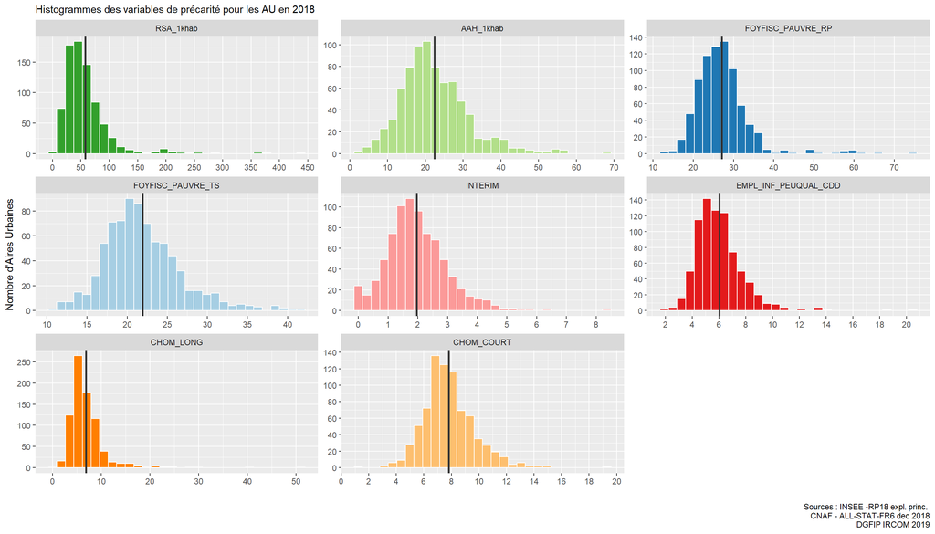

```r
# Preparation du tableau
## tableau variables relatives uniquement
df2 <- df %>%
  select(AU2010, all_of(VarRelIntensite))

## ajout des labels avec le package labelled

var_label(df2) <- DicoVar %>%
  pull(Label) %>%
  c("Code Aire Urbaine", .)

## tableau variables de stock

df3 <- df %>%
  select(AU2010,all_of(VarStockIntensite))


# Histogrammes multiples à la volée

## Définition des couleurs

# RColorBrewer::display.brewer.pal(name = "Paired", n = 8)
# brewer.pal(n=8,"Paired")

col <-  c("#33A02C" , "#B2DF8A","#1F78B4","#A6CEE3", "#FB9A99", "#E31A1C" ,"#FF7F00",  "#FDBF6F")

## Creation de la planche d'histogramme
  df2 %>%
  pivot_longer(cols = -AU2010,
               names_to = "Variable",
               values_to = "Valeur") %>%
  group_by(Variable) %>%
  mutate(Moyenne = mean(Valeur),
         Mediane = median(Valeur)) %>%
  ungroup() %>%
  mutate(across(Variable, ~factor(., levels=VarRelIntensite))) %>%
  ggplot(aes(x = Valeur, fill = Variable)) +
  geom_histogram(show.legend = FALSE, color = "white") +
  facet_wrap(~ Variable,
             scales = "free") +
  geom_vline(aes(xintercept = Moyenne, group = Variable),
             colour = 'grey20',
             size = 1 ) +
  scale_y_continuous(breaks = scales::pretty_breaks(n = 6)) +
  scale_x_continuous(breaks = scales::pretty_breaks(n = 8)) +
  scale_fill_manual(values = col)+
  labs(subtitle = "Histogrammes des variables de précarité pour les AU en 2018",
       y = "Nombre d'Aires Urbaines", x = "",
       caption = "Sources : INSEE -RP18 expl. princ. \n CNAF - ALL-STAT-FR6 dec 2018\n DGFIP IRCOM 2019")
```

```r
# Distances à la moyenne des AU

## Calcul du profil moyen
meanProfileAU <- dfResume %>%
  select(Variable, Moyenne) %>%
  mutate(AU2010 = "999",
         LIBAU2010 = "Moyennes des AU") %>%
  pivot_wider(id_cols=  c(AU2010, LIBAU2010), names_from = Variable, values_from = Moyenne)

## Calcul d'une distance euclidienne au profil moyen

distAllAU <- df2  %>%
  mutate(across(where(is.numeric), function(x) x - mean(x, na.rm = TRUE))) %>%
  # on normalise les résultats en colonnes pour la comparabilité.
  mutate(across(where(is.numeric), scale)) %>%
  rowwise %>%
  # l'indicateur créé est donc la somme en valeur absolue des écarts à la moyenne (normalisés)
  mutate(DistMeanAU = sum(abs(c_across(where(is.numeric))))) %>%
  ungroup()


## les 10 AU les plus proches de la moyenne
closest_10_mean <- distAllAU %>%
  slice_min(DistMeanAU, n = 10) %>%
  pull(AU2010)

top10mean <-df2 %>%
  ungroup() %>%
filter(AU2010 %in%  closest_10_mean) %>%
  left_join(au_info,
            by = "AU2010") %>%
  left_join(select(distAllAU, AU2010,DistMeanAU),
            by = "AU2010") %>%
  bind_rows(meanProfileAU) %>%
  relocate(AU2010, LIBAU2010, LIBDEP, LIBREG, DistMeanAU)
```

### 2.2.2 Cartographie exploratoire

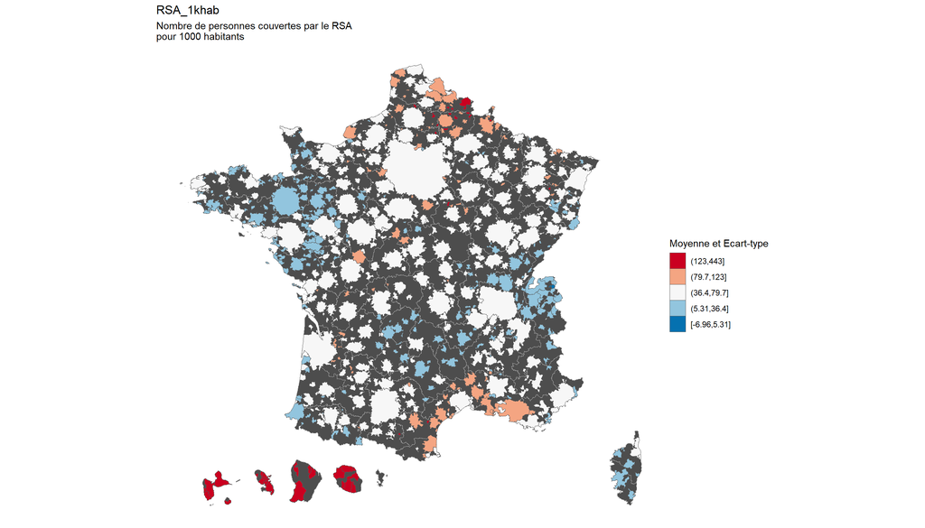

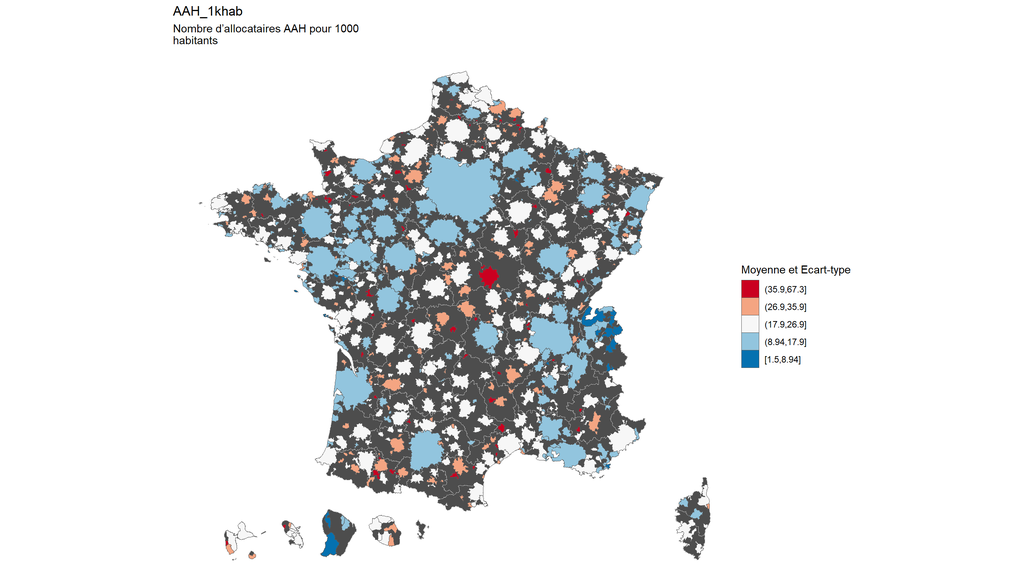

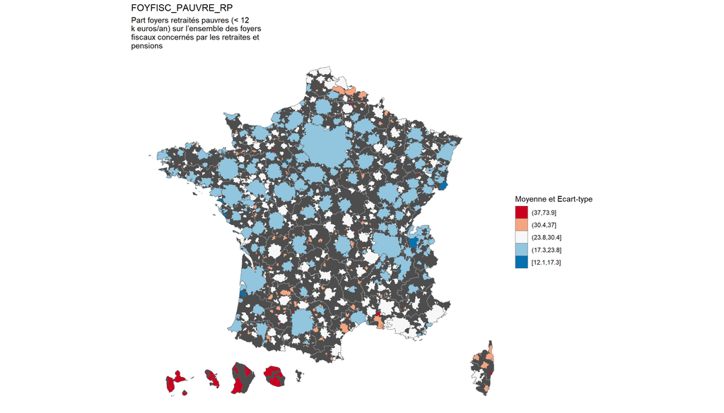

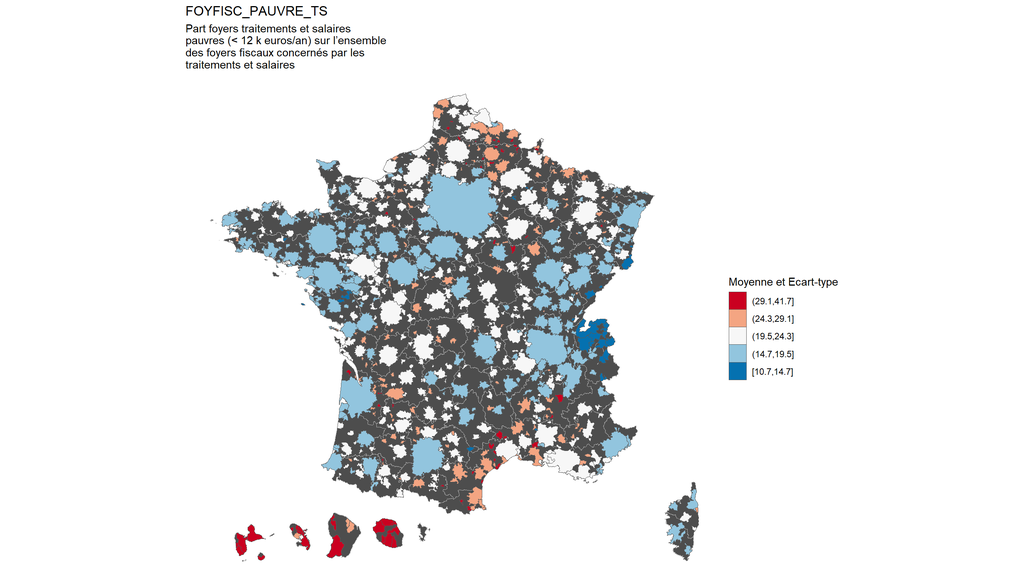

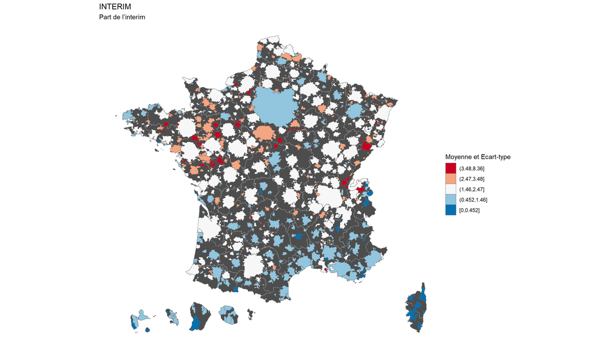

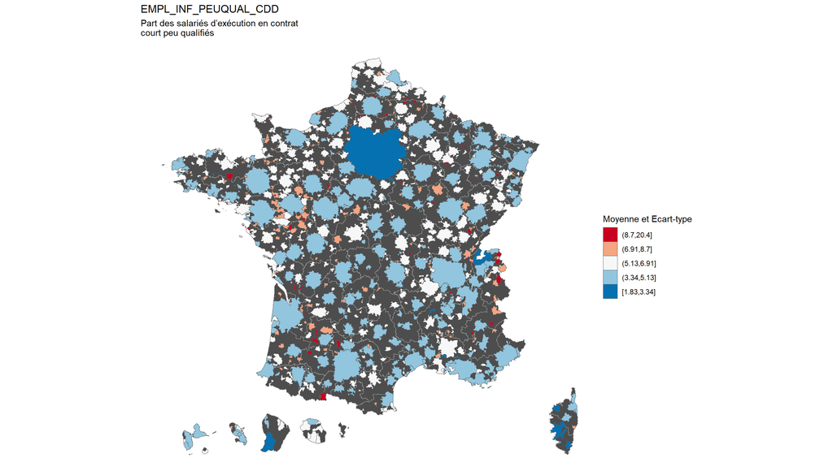

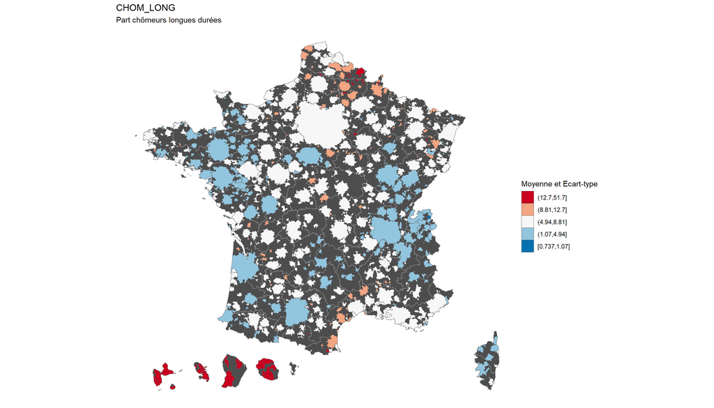

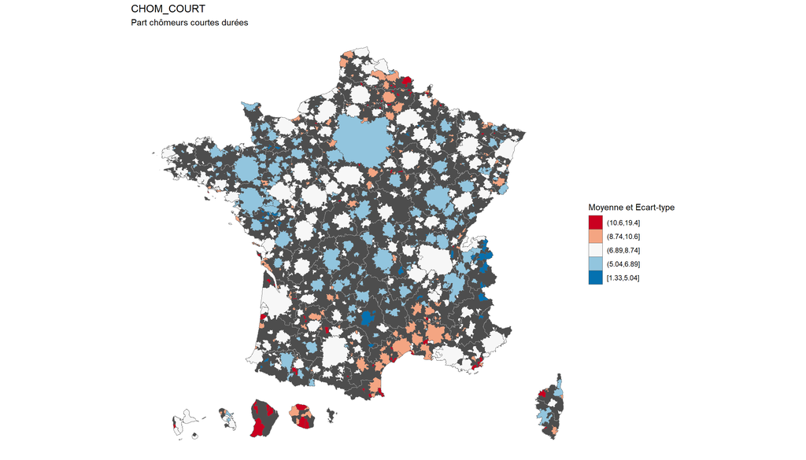

```r
# fonction de calcul moyenne écart type


 meanEC <- function(x){c(min(x, na.rm = TRUE), mean(x, na.rm = TRUE)-1.5*sd(x, na.rm = TRUE), mean(x, na.rm = TRUE)-0.5*sd(x, na.rm = TRUE), mean(x, na.rm = TRUE)+0.5*sd(x, na.rm = TRUE), mean(x, na.rm = TRUE)+1.5*sd(x, na.rm = TRUE), max(x, na.rm = TRUE))}

# Préparation du tableau pour la cartographie (format long)
dfcarto <- df2 %>%
  pivot_longer(cols = -AU2010,
               names_to = "Variable",
               values_to = "Valeur") %>%
  group_by(Variable) %>%
  mutate(Classe = cut(Valeur,
                      breaks = meanEC(x=Valeur) ,
                      dig.lab = 3,
                      include.lowest = TRUE)) %>%
  ungroup() %>%
  left_join(select(AUsf, AU2010)) %>%
  left_join(select(DicoVar, Variable, Label)) %>%
  left_join(select(au_info, AU2010, LIBAU2010, pop18_au)) %>%
  # wrap des labels
  mutate(Label = str_wrap(Label, width = 40)) %>%
  st_sf

# Fonction de cartographie automatique
MapMeanEC <- function(Var){

  ggplot() +
    geom_sf(data = depsf, fill = "grey30", color = "grey70", size = 0.5) +
    geom_sf(data = dfcarto %>% filter(Variable == all_of(Var)),
            mapping = aes(fill = Classe ), lwd = 0) +
    labs(title = Var,
         subtitle = dfcarto  %>%
           filter(Variable == all_of(Var)) %>%
                    st_drop_geometry %>%
                    select(Label) %>%
                    unique %>%
                    pull,
         fill = "Moyenne et Ecart-type") +
     scale_fill_manual(values = rev(brewer.pal(n = 5, "RdBu")))+
    theme_void() +
    guides(fill = guide_legend(reverse = TRUE))
}

# Boucle d'itération sur les 8 variables

for(i in unique(dfcarto$Variable)){
  plot(MapMeanEC(Var = i))

}
```

La distribution dissymétrique de la variable RSA (Nb de personnes couvertes par le RSA pour 1 000 habitants) ne permet pas sa représentation correcte avec une dicrétisation selon la moyenne et l’écart-type.

##### 2.2.2.0.1 Cartographie des trois variables

Production des cartes pour trois variables, telles qu’elles sont présentées dans l’article. La discrétisation moyenne - écart-type est conservée pour la cartographie des variables de “Part des foyers retraités pauvres” et de “Part des salariés d’exécution en contrat court peu qualifiés”, et une discrétisation manuelle à partir d’une progression géométrique est proposée pour la cartographie des “Personnes couvertes par le RSA pour 1 000 habitants”.

```r
# Paramètres communs
n_top_labels <- 20

#  Paramètre pour la sélection personnalisée des labels
# Si NULL, utilise le top n_top_labels basé sur la valeur
# Si vecteur de noms, utilise ces noms spécifiques
custom_labels_selection <- NULL  # Par défaut, utilise le système existant

# Paramètres pour geom_text_repel
label_repel_params <- list(
  size = 2.5,                      # Taille du texte des labels
  box.padding = 0.3,               # Espace entre la boîte du label et les autres éléments
  point.padding = 0.3,             # Distance minimale entre le label et le point qu'il désigne
  segment.size = 0.4,              # Épaisseur des lignes de connexion
  segment.alpha = 0.8,             # Transparence des lignes de connexion (0-1)
  segment.color = "black",        # Couleur des lignes de connexion
  label.padding = 0.2,             # Espace à l'intérieur du label (marges internes)
  label.size = 0.1,                # Épaisseur de la bordure du label
  label.r = 0.1,                   # Rayon des coins arrondis du label
  fill = alpha("white", 0.8),      # Couleur de fond des labels avec transparence
  max.overlaps = Inf,              # Nombre maximum de chevauchements autorisés (Inf = tous affichés)
  force = 2,                       # Force de répulsion entre les labels (plus élevé = plus espacés)
  min.segment.length = 0,          # Longueur minimale des segments (0 = tous affichés)
  max.iter = 2000,                 # Nombre maximum d'itérations pour l'algorithme de positionnement
  nudge_x = 0.1,                   # Décalage horizontal de tous les labels (réduit)
  nudge_y = 0.1,                   # Décalage vertical de tous les labels (réduit)
  direction = "both" ,              # Direction de répulsion ("both", "x", "y")
  xlim = c(-Inf, Inf),                # Permet aux labels de dépasser les limites
  ylim = c(-Inf, Inf)                 # Permet aux labels de dépasser les limites verticales
)

# Sélection des données pour les labels
select_label_data <- function(data, custom_selection = NULL, n_top = n_top_labels) {
  if (is.null(custom_selection)) {
    # Comportement original : top n basé sur la valeur
    return(data %>% slice_max(order_by = Valeur, n = n_top))
  } else {
    # Nouvelle fonctionnalité : sélection personnalisée
    return(data %>% filter(LIBAU2010 %in% custom_selection))
  }
}
```

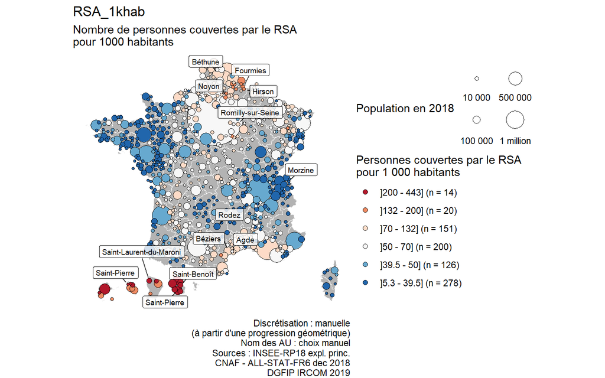

```r
#### Carte 1 RSA #####

# Définir les labels personnalisés pour cette carte (ou NULL pour garder le comportement original)
custom_labels_rsa <- c("Saint-Laurent-du-Maroni", "Saint-Benoît"," Saint-Paul",
                       "Saint-Pierre", "Béthune","Hénin-Beaumont",
                       "Douai", "Valenciennes", "Fourmies",
                       "Hirson", "Noyon", "Romilly-sur-Seine",
                       "Agde", "Béziers", "Morzine", "Rodez")


# Discrétisation manuelle à partir d'une progresssion géométrique
# Définition des breaks et labels et couleurs
bks <- c(5.3, 39.6463887362614, 50, 70, 132.529521103011, 200, 443.018255222047)

labels <- c("]5.3 - 39.5]", "]39.5 - 50]", "]50 - 70]", "]70 - 132]", "]132 - 200]", "]200 - 443]")

col <- c("#2166AC", "#67A9CF", "#F7F7F7", "#FDDBC7", "#EF8A62", "#B2182B")

## Préparation des données

# Discrétisation
carto_rsa <-  dfcarto %>%
  filter(Variable == "RSA_1khab") %>%
  mutate(Classe = cut(Valeur,
                      breaks = bks ,
                      dig.lab = 3,
                      include.lowest = TRUE))

## étendue des cercles prop
rangecircle <- c(1,25)

# contour
contour <- 0.2

# reformatage des classes
old_levels <- c("[5.3,39.6]", "(39.6,50]", "(50,70]", "(70,133]", "(133,200]", "(200,443]")

# Preparation du tableau
carto_rsa <- carto_rsa %>%
  # Recodage des niveaux avec les nouveaux labels
  mutate(Classe = factor(as.character(Classe),
                         levels = old_levels,
                         labels = labels,
                         ordered = TRUE)) %>%
  # Comptage par classe
  group_by(Classe) %>%
  mutate(n_villes = n()) %>%
  ungroup() %>%
  mutate(Classe_label = paste0(Classe, " (n = ", n_villes, ")")) %>%
  mutate(Classe_label = factor(Classe_label,
                               levels = c("]5.3 - 39.5] (n = 278)",
                                          "]39.5 - 50] (n = 126)",
                                          "]50 - 70] (n = 200)",
                                          "]70 - 132] (n = 151)",
                                          "]132 - 200] (n = 20)",
                                          "]200 - 443] (n = 14)")))

# verifications rapides
# table(carto_rsa$Classe)
# table(carto_rsa$Classe_label)

# Création de la carte
g_rsa <- ggplot() +
  geom_sf(data = depsf, fill = "grey70", color = "grey95", size = 0.5) +
  geom_sf(data = carto_rsa %>% st_centroid(),
          mapping = aes(fill = Classe,
                        size = pop18_au),
          pch = 21,
          stroke = contour) +
  do.call(geom_label_repel, c(
    list(
      data = select_label_data(carto_rsa, custom_labels_rsa, n_top_labels) %>% st_centroid(),  # MODIFICATION ICI
      mapping = aes(label = str_wrap(LIBAU2010, 20),
                    geometry = geometry),
      stat = "sf_coordinates"
    ),
    label_repel_params
  )) +
  scale_size(range = rangecircle,
             guide = guide_legend(
               title = "Population en 2018",
               nrow = 2,
               label.position = "bottom",
               direction = "horizontal",
               override.aes = list(stroke = 0.5)),
             breaks = c(10000, 100000, 500000, 1000000),
             labels = c("10 000", "100 000", "500 000", "1 million")) +
  labs(title = "RSA_1khab",
       subtitle = carto_rsa %>%
         st_drop_geometry %>%
         select(Label) %>%
         unique %>%
         pull,
       fill = "Personnes couvertes par le RSA\npour 1 000 habitants",
       caption = "Discrétisation : manuelle\n(à partir d'une progression géométrique)\nNom des AU : choix manuel\nSources : INSEE-RP18 expl. princ.\nCNAF - ALL-STAT-FR6 dec 2018\nDGFIP IRCOM 2019") +
  scale_fill_manual(
    values = col,
    breaks =levels(carto_rsa$Classe),
    labels = levels(carto_rsa$Classe_label)) +
  theme_void() +
  coord_sf(expand = TRUE, clip = "off") + # pour permettre l'affichage des labels hors de la carte
  guides(fill = guide_legend(reverse = TRUE,
                             override.aes = list(size=2, stroke = 0.5)))


# Affichage carte
g_rsa
```

```r
# Version sans titre
g_rsa <- g_rsa  +
  labs(title = "",
       subtitle = "")

# ggsave(plot = g_rsa,
#        path =  "../Output/",
#        filename = "carto_rsa_1khab_2018.png",
#        width = 210,
#        height = 148,
#        dpi = 300,
#        device = "png",
#        units = "mm",
#        bg = "white")
```

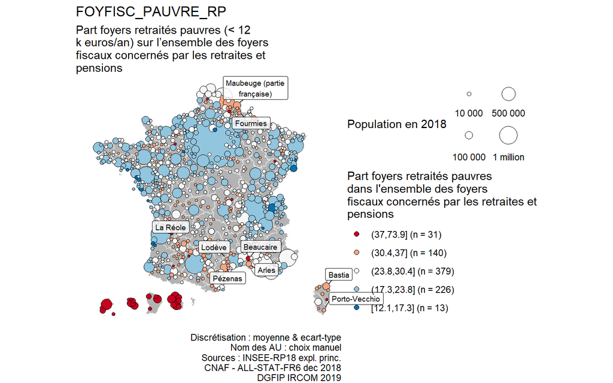

```r
# Carte 2 - Foyers fiscaux pauvres

# Définir les labels personnalisés pour cette carte
custom_labels_foyfisc <- c("Maubeuge (partie française)", "Fourmies", "Bastia",
                           "Porto-Vecchio", "La Réole", "Pézenas",
                           "Arles", "Lodève", "Beaucaire")

# Préparation du tableau
data_foyfisc <- dfcarto %>%
  filter(Variable == "FOYFISC_PAUVRE_RP") %>%
  group_by(Classe) %>%
  mutate(n_villes = n()) %>%
  ungroup() %>%
  mutate(Classe_label = paste0(Classe, " (n = ", n_villes, ")")) %>%
  mutate(Classe = fct_drop(Classe)) %>% # envlever les niveaux inutilisés
  mutate(Classe_label = factor(Classe_label,  # on ordonne manuellement le label
                               levels = c("[12.1,17.3] (n = 13)",
                                          "(17.3,23.8] (n = 226)",
                                          "(23.8,30.4] (n = 379)",
                                          "(30.4,37] (n = 140)",
                                          "(37,73.9] (n = 31)")))

# Carte Foyers fiscaux pauvres
g_foyfisc <- ggplot() +
  geom_sf(data = depsf, fill = "grey70", color = "grey95", size = 0.5) +
  geom_sf(data = data_foyfisc %>% st_centroid(),
          mapping = aes(fill = Classe, size = pop18_au),
          pch = 21,
          stroke = contour) +
  do.call(geom_label_repel, c(
    list(
      data = select_label_data(data_foyfisc, custom_labels_foyfisc, 15) %>% st_centroid(),  # MODIFICATION ICI
      mapping = aes(label =  str_wrap(LIBAU2010, 20),
                    geometry = geometry),
      stat = "sf_coordinates"
    ),
    label_repel_params
  )) +
  scale_size(range = rangecircle,
             guide = guide_legend(
               title = "Population en 2018",
               nrow = 2,
               label.position = "bottom",
               direction = "horizontal",
               override.aes = list(stroke = 0.5)),
             breaks = c(10000, 100000, 500000, 1000000),
             labels = c("10 000", "100 000", "500 000", "1 million")) +
  labs(title = "FOYFISC_PAUVRE_RP",
       subtitle = data_foyfisc %>%
         st_drop_geometry %>%
         select(Label) %>%
         unique %>%
         pull,
       fill = "Part foyers retraités pauvres\ndans l'ensemble des foyers\nfiscaux concernés par les retraites et\npensions",
       caption = "Discrétisation : moyenne & ecart-type\nNom des AU : choix manuel\nSources : INSEE-RP18 expl. princ.\nCNAF - ALL-STAT-FR6 dec 2018\nDGFIP IRCOM 2019") +
  scale_fill_manual(
    values = rev(brewer.pal(n = 5, "RdBu")),
    breaks = levels(data_foyfisc$Classe),
    labels = levels(data_foyfisc$Classe_label)) +
  theme_void() +
  coord_sf(expand = TRUE, clip = "off") +
  guides(fill = guide_legend(reverse = TRUE,
                             override.aes = list(size=2, stroke = 0.5)))


# Affichage carte
g_foyfisc
```

```r
# Version sans titre
g_foyfisc <- g_foyfisc +
  labs(title = "",
       subtitle = "")

# ggsave(plot = g_foyfisc,
#        path =  "../Output/",
#        filename = "carto_foyrp_pauvre_2018.png",
#        width = 210,
#        height = 148,
#        dpi = 300,
#        device = "png",
#        units = "mm",
#        bg = "white")
```

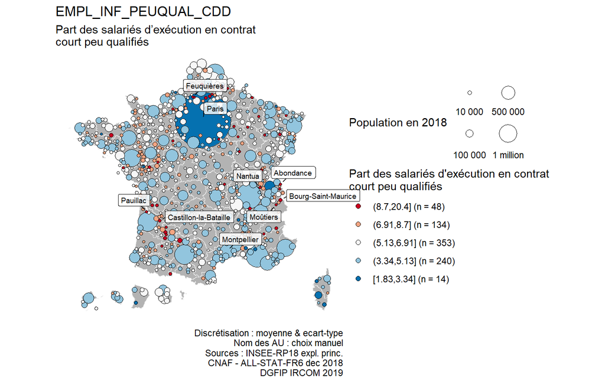

```r
# Carte 3 - Emplois peu qualifiés en CDD

# Définir les labels personnalisés pour cette carte
custom_labels_empl <- c("Paris", "Montpellier", "Moûtiers",
                        "Pauillac", "Feuquières", "Abondance",
                        "Nantua", "Bourg-Saint-Maurice", "Castillon-la-Bataille")

# Preparation du tableau
data_empl <- dfcarto %>%
  filter(Variable == "EMPL_INF_PEUQUAL_CDD") %>%
  group_by(Classe) %>%
  mutate(n_villes = n()) %>%
  ungroup() %>%
  mutate(Classe_label = paste0(Classe, " (n = ", n_villes, ")")) %>%
  mutate(Classe = fct_drop(Classe)) %>% # envlever les niveaux inutilisés
  mutate(Classe_label = factor(Classe_label,  # on ordonne manuellement le label
                               levels = c("[1.83,3.34] (n = 14)",
                                          "(3.34,5.13] (n = 240)",
                                          "(5.13,6.91] (n = 353)",
                                          "(6.91,8.7] (n = 134)",
                                          "(8.7,20.4] (n = 48)")))

# Carte Emplois peu qualifiés
g_empl <- ggplot() +
  geom_sf(data = depsf, fill = "grey70", color = "grey95", size = 0.5) +
  geom_sf(data = data_empl %>% st_centroid(),
          mapping = aes(fill = Classe, size = pop18_au),
          pch = 21,
          stroke = contour) +
  do.call(geom_label_repel, c(
    list(
      data = select_label_data(data_empl, custom_labels_empl, n_top_labels) %>% st_centroid(),  # MODIFICATION ICI
      mapping = aes(label = str_wrap(LIBAU2010, 20),
                    geometry = geometry),
      stat = "sf_coordinates"
    ),
    label_repel_params
  )) +
  scale_size(range = rangecircle,
             guide = guide_legend(
               title = "Population en 2018",
               nrow = 2,
               label.position = "bottom",
               direction = "horizontal",
               override.aes = list(stroke = 0.5)),
             breaks = c(10000, 100000, 500000, 1000000),
             labels = c("10 000", "100 000", "500 000", "1 million")) +
  labs(title = "EMPL_INF_PEUQUAL_CDD",
       subtitle = data_empl %>%
         st_drop_geometry %>%
         select(Label) %>%
         unique %>%
         pull,
       fill = "Part des salariés d'exécution en contrat\ncourt peu qualifiés",
       caption = "Discrétisation : moyenne & ecart-type\nNom des AU : choix manuel\nSources : INSEE-RP18 expl. princ.\nCNAF - ALL-STAT-FR6 dec 2018\nDGFIP IRCOM 2019") +
  scale_fill_manual(
    values = rev(brewer.pal(n = 5, "RdBu")),
    breaks = levels(data_empl$Classe),
    labels = levels(data_empl$Classe_label)) +
  theme_void() +
  coord_sf(expand = TRUE, clip = "off") +
  guides(fill = guide_legend(reverse = TRUE,
                             override.aes = list(size=2, stroke = 0.5)))

# Affichage de la carte
g_empl
```

```r
# Version sans titre
g_empl <- g_empl +
  labs(title = "",
       subtitle = "")

# ggsave(plot = g_empl,
#        path =  "../Output/",
#        filename = "carto_emppeuqual_cdd_2018.png",
#        width = 210,
#        height = 148,
#        dpi = 300,
#        device = "png",
#        units = "mm",
#        bg = "white")
```

## 2.3 Relations bivariées

Corrélation entre les 8 variables d’intérêt.

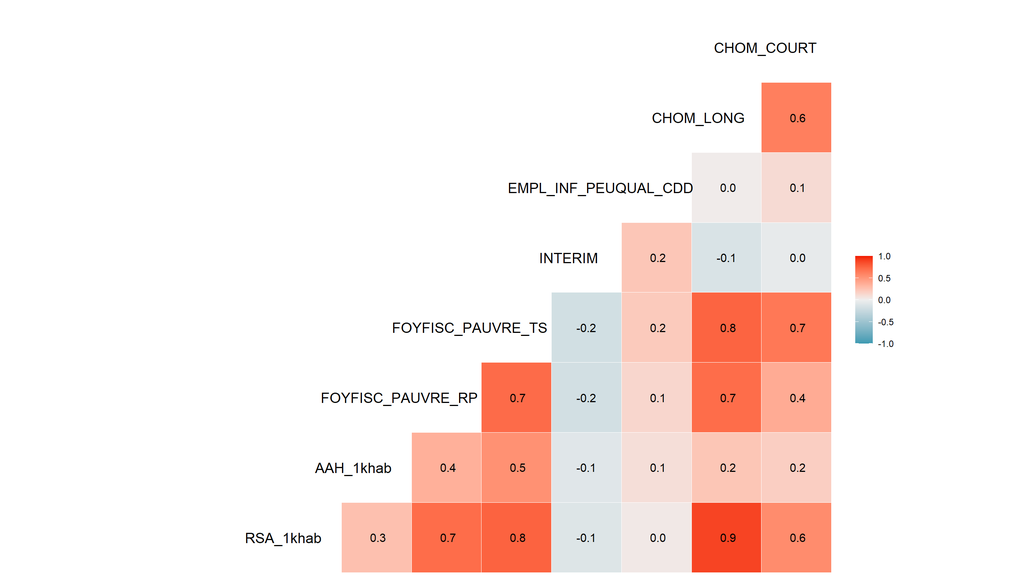

```r
#### bivariés ####

ggcorr(df2 %>% select_if(is.numeric),
       label = TRUE,
       hjust = 0.8,
       size = 5, layout.exp = 2 )
```

On retrouve une correlation assez forte entre la variable du RSA et les variables du chômage et ou de la pauvreté monétaire (foyer fiscaux).

Les variables concernant plus directement les formes d’emploi (Interim et CDD peu qualifiés) semblent peu corrélées avec le reste.

## 2.4 Effet taille : appréhension de la hiérarchie urbaine

On aborde l’effet “taille” des villes avec les variables de stock et un modèle linéaire log-log avec la population. Ces analyses se retrouvent dans la partie 2.3 de l’article.

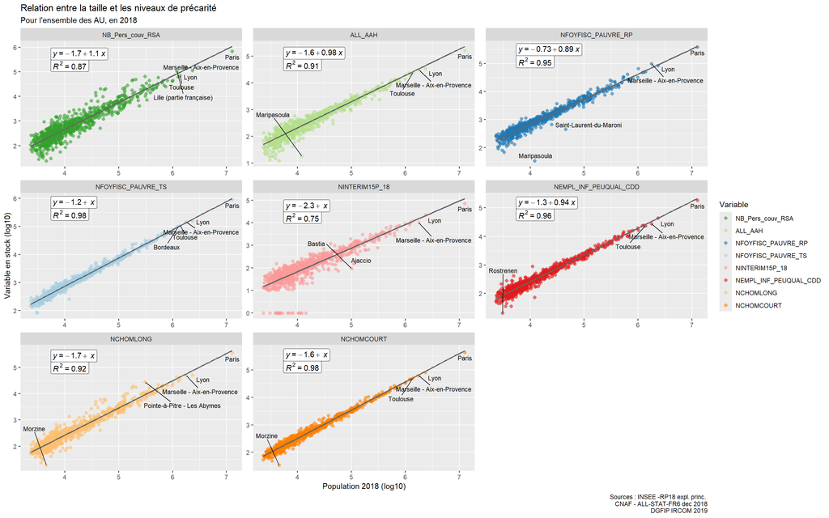

```r
# test effet taille

## Préparation du tableau et gestion des 0
#(soit les remplacer par 1, soit les filtrer : cela ne change pas grand chose donc on garde les 0 en les remplaçant par 1, car log10(1) = 0)

dflog <- df3 %>%
  left_join(select(df, AU2010,P18_POP_rp18), by = "AU2010") %>%
  mutate(across(where(is.numeric), ~ replace(., . == 0 , 1))) %>% # remplacer les zero par 1 ou filtrer les 0 (lignes du dessous)
  # filter_all(. ,all_vars(. > 0)) %>%  #CHOISIR SI ON ENLEVE LES 0 ou Non
  mutate(across(where(is.numeric), ~log10(.))) %>%
  mutate(ranksize = Rank(P18_POP_rp18, decreasing = TRUE))

# format long
dflog <- dflog %>%
  pivot_longer(-c(AU2010,P18_POP_rp18, ranksize), names_to = "Var", values_to = "Valeur")
# mutate(Valeur =  ifelse(is.infinite(Valeur), 0, Valeur)) # gestion des infinis (0 en log)

# préparation du tableau pour graphique : gestion des variables en facteur

dflog <- dflog %>%
  mutate(across(Var, ~factor(., levels=VarStockIntensite))) %>%
  left_join(select(au_info, AU2010, LIBAU2010,LIBREG), by = "AU2010")

# vecteur de couleurs

col <-  c("#33A02C" , "#B2DF8A","#1F78B4","#A6CEE3", "#FB9A99", "#E31A1C" , "#FDBF6F" ,"#FF7F00")


# fonction de ggpubr utile pour production d'un facet présentant les 8 relations log log (variables vs population)

ggscatter(dflog, x = "P18_POP_rp18" ,
          y = "Valeur",
          color = "Var",
          palette = col,
          add = "reg.line",
          add.params = list(color = "grey40",
                            size = 0.75),
          ggtheme = theme_grey(),
          alpha = 0.6,
          shape = 16) +
  facet_wrap(~Var, scales = "free") +
  stat_cor(aes(label = after_stat(rr.label)),
           label.y.npc = 0.9,
           label.x.npc = 0.1,
           geom = "label" ) +
  stat_regline_equation(label.y.npc= 1,
                        label.x.npc = 0.1,
                        geom = "label",
                        digits = 3 ) +
  stat_dens2d_labels(aes(label =  LIBAU2010),
                     # keep.fraction = 0.005,
                     orientation = "y",
                     # keep.sparse = TRUE,
                     keep.number = 5,
                     geom = "text_repel",
                     # position = position_nudge_center(x = 0.05,
                     #                                  y = 0.05,
                     #                                  center_x = 0,
                     #                                  center_y = 0),
                     vjust = "outward",
                     hjust = "inward",
                     size = 3) +
  labs(title = "Relation entre la taille et les niveaux de précarité",
       subtitle = "Pour l'ensemble des AU, en 2018",
       x = "Population 2018 (log10)",
       y = "Variable en stock (log10)",
       color = "Variable",
       caption = "Sources : INSEE -RP18 expl. princ. \n CNAF - ALL-STAT-FR6 dec 2018\n DGFIP IRCOM 2019")
```

```r
## Production d'un tableau avec les intervalles de confiance sur les betas
library(broom)

# Fonction pour effectuer la régression et calculer l'intervalle de confiance
perform_regression <- function(data, var) {
  model <- lm(Valeur ~ P18_POP_rp18, data = filter(data, Var == var))

  # Coefficients avec IC
  tidy_model <- tidy(model, conf.int = TRUE, conf.level = 0.95)
  coef_result <- tidy_model %>% filter(term == "P18_POP_rp18")

  # Statistiques du modèle
  model_stats <- glance(model)

  # Combiner
  result <- coef_result %>%
    mutate(Var = var,
           R_squared = model_stats$r.squared,
           adj_R_squared = model_stats$adj.r.squared)

  return(result)
}

# Appliquer la fonction à chaque variable
regression_results <- dflog %>%
  distinct(Var) %>%
  pull(Var) %>%
  map_dfr(~perform_regression(dflog, .)) %>%
  mutate(Var = distinct(dflog, Var) %>% pull(Var))

# Afficher les résultats
print(regression_results %>%
        select(Var, estimate, conf.low, conf.high, R_squared) %>%
        rename(beta = estimate,
               CI_lower = conf.low,
               CI_upper = conf.high))
```

```
## # A tibble: 8 × 5
##   Var                    beta CI_lower CI_upper R_squared
##   <fct>                 <dbl>    <dbl>    <dbl>     <dbl>
## 1 NB_Pers_couv_RSA      1.09     1.06     1.12      0.865
## 2 ALL_AAH               0.981    0.959    1.00      0.910
## 3 NFOYFISC_PAUVRE_RP    0.892    0.878    0.906     0.950
## 4 NFOYFISC_PAUVRE_TS    1.01     0.996    1.02      0.980
## 5 NINTERIM15P_18        1.04     1.00     1.09      0.750
## 6 NEMPL_INF_PEUQUAL_CDD 0.939    0.926    0.953     0.961
## 7 NCHOMLONG             1.04     1.02     1.06      0.925
## 8 NCHOMCOURT            1.03     1.02     1.04      0.979
```

Test de robustesse : tableau des résultats en retirant Paris (AU2010 = 001).

```r
# même code mais en enlevant paris (quasi-outlier) pour robustesse des résultats

dflog2 <- dflog %>%
  # enlever Paris
  filter(AU2010 != "001")

regression_results2 <- dflog2 %>%
  distinct(Var) %>%
  pull(Var) %>%
  map_dfr(~perform_regression(dflog2, .)) %>%
  mutate(Var = distinct(dflog2, Var) %>% pull(Var))

# Afficher les résultats
print(regression_results2 %>%
        select(Var, estimate, conf.low, conf.high, R_squared) %>%
        rename(beta = estimate,
               CI_lower = conf.low,
               CI_upper = conf.high))
```

```
## # A tibble: 8 × 5
##   Var                    beta CI_lower CI_upper R_squared
##   <fct>                 <dbl>    <dbl>    <dbl>     <dbl>
## 1 NB_Pers_couv_RSA      1.09     1.06     1.12      0.862
## 2 ALL_AAH               0.982    0.961    1.00      0.908
## 3 NFOYFISC_PAUVRE_RP    0.892    0.878    0.907     0.949
## 4 NFOYFISC_PAUVRE_TS    1.01     0.997    1.02      0.979
## 5 NINTERIM15P_18        1.05     1.00     1.09      0.745
## 6 NEMPL_INF_PEUQUAL_CDD 0.940    0.927    0.954     0.960
## 7 NCHOMLONG             1.04     1.02     1.06      0.923
## 8 NCHOMCOURT            1.03     1.02     1.04      0.978
```

Observation : les résultats restent stables avec ou sans l’AU de Paris (AU2010 = 001).

Création de la planche avec les trois relations log-log, en conservant Paris.

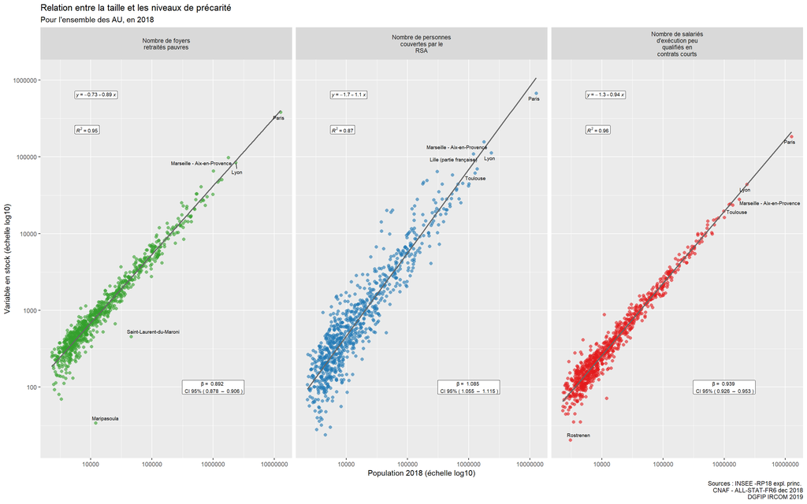

```r
# sous selection avec les trois variables présentées dans l'artcile
dflog2 <- dflog %>%
  filter(Var %in%  c("NB_Pers_couv_RSA", "NFOYFISC_PAUVRE_RP","NEMPL_INF_PEUQUAL_CDD" )) %>%
  mutate(VarName = case_when(Var == "NB_Pers_couv_RSA" ~ "Nombre de personnes couvertes par le RSA",
                             Var == "NFOYFISC_PAUVRE_RP" ~ "Nombre de foyers retraités pauvres",
                             T ~ "Nombre de salariés d'exécution peu qualifiés en contrats courts"))

# retransformation en valeurs brutes pour les axes x et y

dflog2 <- dflog2 %>%
  mutate(P18_POP_rp18 = 10^P18_POP_rp18,
         Valeur = 10^Valeur)

# vecteur de couleurs
col <-  c("#33A02C" , "#1F78B4","#E31A1C" )


# tableau avec valeur et intervalle de confiance :
df_ci <- regression_results %>%
  select(Var, estimate, conf.low, conf.high) %>%
  rename(beta = estimate,
         CI_lower = conf.low,
         CI_upper = conf.high) %>%
  filter(Var %in%  c("NB_Pers_couv_RSA", "NFOYFISC_PAUVRE_RP","NEMPL_INF_PEUQUAL_CDD" )) %>%
  mutate(across(where(is.numeric), ~round(., 3)))

dflog2 <- dflog2 %>%
  left_join(df_ci)
# change function for digits in equation : https://stackoverflow.com/questions/66177005/im-using-stat-regline-equation-with-ggscatter-is-there-a-way-to-specify-the-si
# trace(ggpubr:::.stat_lm, edit = TRUE)
# ligne 13-14  : eq.char <- as.character(signif(polynom::as.polynomial(coefs), 3))

g <- ggscatter(dflog2, x = "P18_POP_rp18" ,
               y = "Valeur",
               color = "VarName",
               palette = col,
               add = "reg.line",
               add.params = list(color = "grey40", size = 0.75),
               ggtheme = theme_grey(),
               alpha = 0.6,
               shape = 16,
               show.legend.text = FALSE) +
  scale_x_log10() +
  scale_y_log10() +
  facet_wrap(~VarName,
             labeller = labeller(VarName = label_wrap_gen(20))) +
  stat_cor(aes(label = after_stat(rr.label)),
           label.y.npc = 0.9, label.x.npc = 0.1,
           geom = "label", size = 2.5) +
  stat_regline_equation(label.y.npc= 1,
                        label.x.npc = 0.1,
                        geom = "label",
                        digits = 5 ,
                        size = 2.5) +
  stat_dens2d_labels(aes(label =  LIBAU2010),
                     # keep.fraction = 0.005,
                     orientation = "y",
                     # keep.sparse = TRUE,
                     keep.number = 5,
                     geom = "text_repel",
                     # position = position_nudge_center(x = 0.05,
                     #                                  y = 0.05,
                     #                                  center_x = 0,
                     #                                  center_y = 0),
                     vjust = "outward",
                     hjust = "inward",
                     size = 2.5) +
  geom_label( aes(label = paste("β = ", beta, "\n", "CI 95% (", CI_lower, " – ", CI_upper, ")" )),
              x = 6 ,
              y = 2 ,
              size = 2.5) +
  labs(title = "Relation entre la taille et les niveaux de précarité",
       subtitle = "Pour l'ensemble des AU, en 2018",
       x = "Population 2018 (échelle log10)",
       y = "Variable en stock (échelle log10)",
       color = "Variable",
       caption =  "Sources : INSEE -RP18 expl. princ. \n CNAF - ALL-STAT-FR6 dec 2018\n DGFIP IRCOM 2019") +
  #enlever la légende
  theme(legend.position="none")

g
```

```r
g <- g + labs(title = "", subtitle = "")

# ggsave(g, path =  "../Output/", filename = "loglin_3variable.png", device = "png",width = 200, height = 126, units = "mm")
```

## 2.5 Construction voisinage

Cette sous-section du code ne correspond à aucune analyse directement présentée dans l’article, mais elle permet le calcul de différentes matrices de voisinage, étape cruciale pour les analyses d’auto-corrélation spatiale qui suivent.

Ici, beaucoup de tests ont été effectués en faisant varier :

- le type de distances considérées :
  - kilométrique (*dist*),
  - *k* plus proches voisins (*knn*)
  - [Graphe de Gabriel](https://fr.wikipedia.org/wiki/Graphe_de_Gabriel) (*gabriel*)
- le type de matrice pour les k plus proches voisins (*symetric = TRUE/FALSE*) :
  - symétrique : si A est considéré comme voisin de B, alors B est automatiquement voisin de A
  - non symétrique : B peut être le plus proche voisin de A, alors que A n’est pas le plus proche voisin de B
- Les paramètres propres aux distances (*param*) :
  - Seuils métriques
  - Nombres de plus proches voisins

NOTE : Pour alléger le code, les fonctions de calcul ont été mises dans un fichier à part : `funtions.R`. Le code repose principalement sur les fonctions du [package sp](https://cran.r-project.org/web/packages/sp/index.html). Le code a été produit et testé de manière linéaire par les auteurices, mais sa factorisation et mise en fonction a été facilitée par l’IA d’Anthropic Claude.

Les spécificités du code mis en fonctions sont la gestion des différents types de distances (ne prenant pas en compte les même paramètres) pour calculer les différentes matrices de voisinage. Et la gestion des DROM (qui sont ici dans une configuration spatiale rapprochée, pour la cartographie, et que l’on traite séparément afin de ne pas créer des voisinages “artificiels” entre leurs AU respectives).

Les étapes de création des voisinages et de calculs d’auto-corrélation spatiale étant intensives (et longues), les fichiers de résultats ont été enregistrés préalablement dans le dossier `/Output` : ainsi les fonctions d’execution sont ici commentées, et les fichiers de résultats sont simplement chargés.

```r
library(sp)
library(spdep)
 # remotes::install_github("adeverse/adespatial")  # voir : https://github.com/adeverse/adespatial
## tuto : https://cran.r-project.org/web/packages/adespatial/vignettes/tutorial.html
# install.packages("adespatial")
library(adespatial)


# tranformation en lambert 93 et ajout d'une variable France hexagonale ou DROM

AUsf_93 <- AUsf %>%
  st_transform(crs = 2154) %>%
  left_join(select(au_info, AU2010, REG)) %>%
  mutate(GROUP_REG = as.character(case_when(REG %in% c(1:4, 94) ~ REG,
                               TRUE ~ 999))) %>%
  select(- REG)

#### créer les centroides


AU_centr <- AUsf_93 %>%
  st_centroid()

# récupérer les coordonnées géographiques des centroids
coord_centr <- AU_centr %>% st_coordinates()

# listw.explore() # pour tester différentes configuration. Approche graph Gabriel intéressante en termes de nombre de voisins


# chargements des fonctions créées

source("functions.R")

# Utilisation des fonctions

## vecteur de nombre de voisins
k_values <- c(1, 2, 3,4 ,10, 20 )
## vecteurs de distances en mètres
dist_values <- c(5000, 10000, 15000, seq(20000, 250000, 10000) )
# distance pour les centroids
dist_values_points <- c( 50000)


# création des listes de voisinage (long à calculer)

# neighborhood_configs <- create_neighborhood_configs(AUsf_93, AU_centr, k_values, dist_values, dist_values_points, group_column = "GROUP_REG")

# saveRDS(neighborhood_configs, "../Output/voisinage_AU.rds")

 neighborhood_configs <- readRDS("../Output/voisinage_AU.rds")

# Affichage d'un résumé des configurations
config_summary <- map_df(neighborhood_configs, function(.) {
  data.frame(
    type = .$config$type,
    method = .$config$method,
    param = .$config$param,
    symmetric = .$config$symmetric,
    n_components = .$n_components,
    avg_neighbors = round(.$avg_neighbors, 2),
    med_neighbors = round(.$med_neighbors, 2),
    min_neighbors = round(.$min_neighbors, 2),
    max_neighbors = round(.$max_neighbors, 2),
    q1_neighbors = round(.$q1_neighbors, 2),
    q3_neighbors = round(.$q3_neighbors, 2)
  )
}, .id = "name")


# résumé des configurations de voisinages
kable(config_summary, row.names = FALSE)
```

| name | type | method | param | symmetric | n_components | avg_neighbors | med_neighbors | min_neighbors | max_neighbors | q1_neighbors | q3_neighbors |
| --- | --- | --- | --- | --- | --- | --- | --- | --- | --- | --- | --- |
| polygon_dist_5000_FALSE | polygon | dist | 5000 | FALSE | 133 | 2.32 | 2 | 0 | 19 | 1 | 3 |
| polygon_dist_10000_FALSE | polygon | dist | 10000 | FALSE | 29 | 3.66 | 3 | 0 | 24 | 2 | 5 |
| polygon_dist_15000_FALSE | polygon | dist | 15000 | FALSE | 11 | 5.13 | 5 | 0 | 26 | 3 | 6 |
| polygon_dist_20000_FALSE | polygon | dist | 20000 | FALSE | 8 | 6.62 | 6 | 0 | 31 | 4 | 8 |
| polygon_dist_30000_FALSE | polygon | dist | 30000 | FALSE | 7 | 10.00 | 9 | 0 | 45 | 7 | 12 |
| polygon_dist_40000_FALSE | polygon | dist | 40000 | FALSE | 6 | 14.01 | 13 | 1 | 61 | 10 | 17 |
| polygon_dist_50000_FALSE | polygon | dist | 50000 | FALSE | 6 | 18.44 | 18 | 2 | 70 | 14 | 22 |
| polygon_dist_60000_FALSE | polygon | dist | 60000 | FALSE | 6 | 23.47 | 23 | 3 | 80 | 18 | 29 |
| polygon_dist_70000_FALSE | polygon | dist | 70000 | FALSE | 6 | 29.09 | 28 | 3 | 100 | 23 | 35 |
| polygon_dist_80000_FALSE | polygon | dist | 80000 | FALSE | 6 | 35.27 | 35 | 3 | 117 | 28 | 43 |
| polygon_dist_90000_FALSE | polygon | dist | 90000 | FALSE | 6 | 41.65 | 42 | 3 | 139 | 34 | 49 |
| polygon_dist_100000_FALSE | polygon | dist | 100000 | FALSE | 6 | 48.72 | 49 | 3 | 153 | 40 | 58 |
| polygon_dist_110000_FALSE | polygon | dist | 110000 | FALSE | 6 | 56.19 | 57 | 3 | 163 | 47 | 66 |
| polygon_dist_120000_FALSE | polygon | dist | 120000 | FALSE | 6 | 64.05 | 66 | 3 | 177 | 54 | 76 |
| polygon_dist_130000_FALSE | polygon | dist | 130000 | FALSE | 6 | 72.02 | 74 | 3 | 186 | 61 | 85 |
| polygon_dist_140000_FALSE | polygon | dist | 140000 | FALSE | 6 | 80.39 | 82 | 3 | 202 | 68 | 95 |
| polygon_dist_150000_FALSE | polygon | dist | 150000 | FALSE | 6 | 89.20 | 91 | 3 | 216 | 75 | 106 |
| polygon_dist_160000_FALSE | polygon | dist | 160000 | FALSE | 6 | 97.97 | 101 | 3 | 229 | 82 | 117 |
| polygon_dist_170000_FALSE | polygon | dist | 170000 | FALSE | 6 | 107.38 | 112 | 3 | 241 | 90 | 129 |
| polygon_dist_180000_FALSE | polygon | dist | 180000 | FALSE | 6 | 117.26 | 122 | 3 | 257 | 97 | 141 |
| polygon_dist_190000_FALSE | polygon | dist | 190000 | FALSE | 6 | 127.14 | 134 | 3 | 270 | 103 | 155 |
| polygon_dist_200000_FALSE | polygon | dist | 200000 | FALSE | 6 | 137.47 | 145 | 3 | 286 | 111 | 168 |
| polygon_dist_210000_FALSE | polygon | dist | 210000 | FALSE | 6 | 147.98 | 155 | 3 | 301 | 119 | 182 |
| polygon_dist_220000_FALSE | polygon | dist | 220000 | FALSE | 6 | 158.76 | 166 | 3 | 320 | 128 | 198 |
| polygon_dist_230000_FALSE | polygon | dist | 230000 | FALSE | 6 | 169.84 | 176 | 3 | 337 | 139 | 212 |
| polygon_dist_240000_FALSE | polygon | dist | 240000 | FALSE | 6 | 181.44 | 188 | 3 | 358 | 147 | 227 |
| polygon_dist_250000_FALSE | polygon | dist | 250000 | FALSE | 6 | 193.04 | 202 | 3 | 377 | 158 | 241 |
| centroid_knn_1_FALSE | centroid | knn | 1 | FALSE | 209 | 1.00 | 1 | 1 | 1 | 1 | 1 |
| centroid_knn_2_FALSE | centroid | knn | 2 | FALSE | 21 | 2.00 | 2 | 2 | 2 | 2 | 2 |
| centroid_knn_3_FALSE | centroid | knn | 3 | FALSE | 7 | 3.00 | 3 | 3 | 3 | 3 | 3 |
| centroid_knn_4_FALSE | centroid | knn | 4 | FALSE | 6 | 3.99 | 4 | 3 | 4 | 4 | 4 |
| centroid_knn_10_FALSE | centroid | knn | 10 | FALSE | 6 | 9.83 | 10 | 3 | 10 | 10 | 10 |
| centroid_knn_20_FALSE | centroid | knn | 20 | FALSE | 6 | 19.45 | 20 | 3 | 20 | 20 | 20 |
| centroid_knn_1_TRUE | centroid | knn | 1 | TRUE | 209 | 1.47 | 1 | 1 | 4 | 1 | 2 |
| centroid_knn_2_TRUE | centroid | knn | 2 | TRUE | 21 | 2.62 | 2 | 2 | 5 | 2 | 3 |
| centroid_knn_3_TRUE | centroid | knn | 3 | TRUE | 7 | 3.73 | 4 | 3 | 7 | 3 | 4 |
| centroid_knn_4_TRUE | centroid | knn | 4 | TRUE | 6 | 4.77 | 5 | 3 | 8 | 4 | 5 |
| centroid_knn_10_TRUE | centroid | knn | 10 | TRUE | 6 | 11.28 | 11 | 3 | 18 | 10 | 12 |
| centroid_knn_20_TRUE | centroid | knn | 20 | TRUE | 6 | 22.03 | 22 | 3 | 33 | 20 | 24 |
| centroid_dist_50000_FALSE | centroid | dist | 50000 | FALSE | 9 | 9.98 | 10 | 0 | 23 | 7 | 13 |
| centroid_gabriel_NA_TRUE | centroid | gabriel | NA | TRUE | 6 | 4.17 | 4 | 1 | 8 | 3 | 5 |

Autre résumé cartographique des configurations de voisinage des AU, avec le code ci-dessous (peu lisible, vraiment exploratoire)

```r
# Visualisation de chaque configuration (optionnel)


# for (i in seq_along(neighborhood_configs)) {
#   config <- neighborhood_configs[[i]]
#   print(paste("Configuration de voisinage", i))
#   create_simple_plot(config, if(config$config$type == "polygon") AUsf_93 else AU_centr)
# }
```

Histogrammes et diagrammes en bâtons pour évaluer les configurations de voisinages selon la distribution du nombre de voisins.

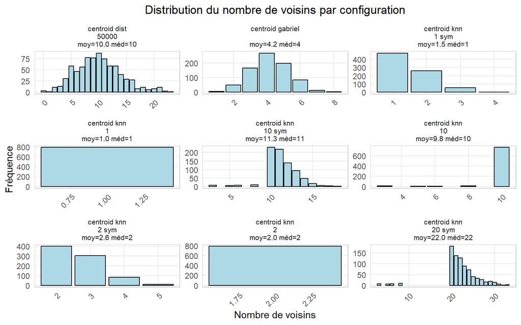

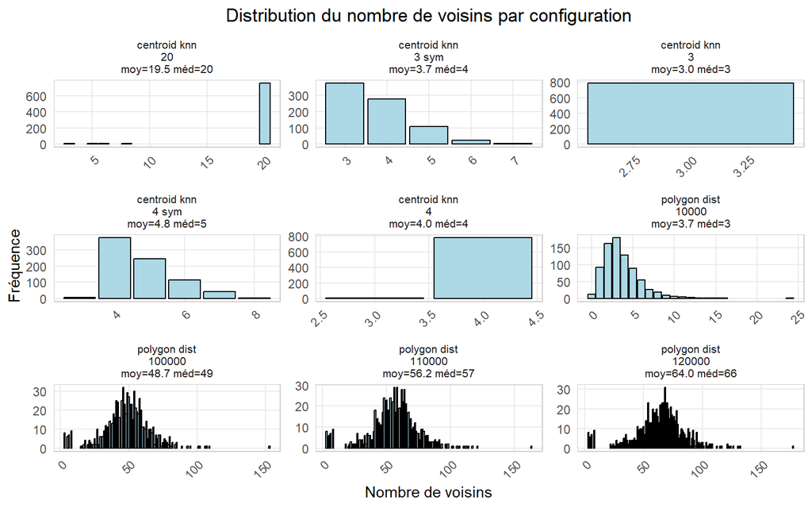

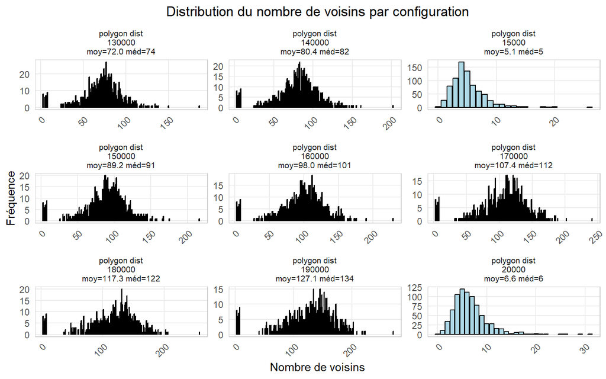

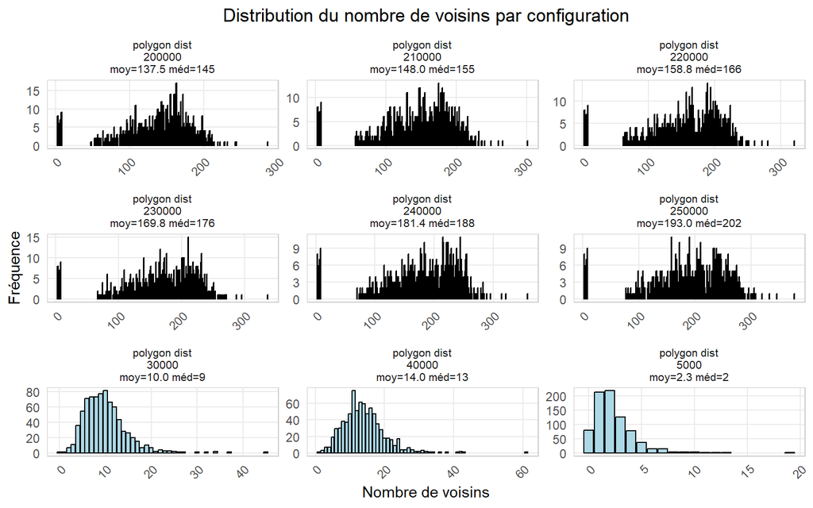

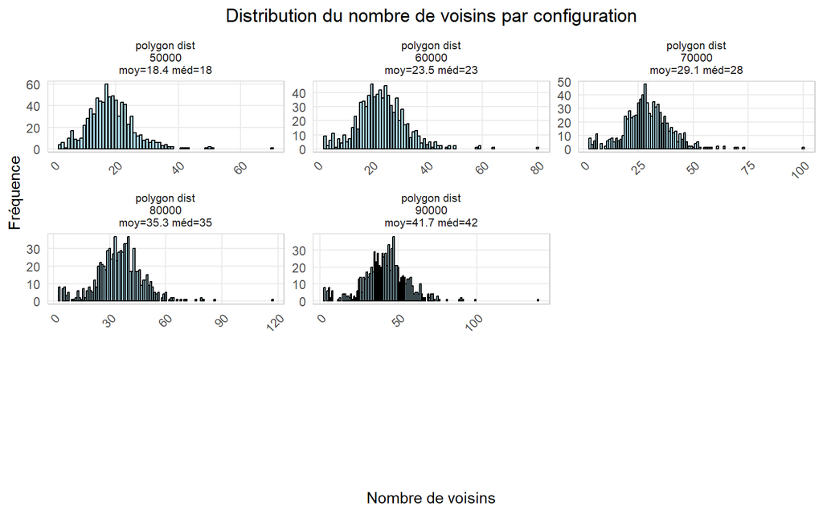

```r
# Création du dataframe avec résumés statistiques
neighbor_distributions <- map_df(neighborhood_configs, function(config) {
  card_values <- card(config$nb)
  data.frame(
    name = paste(config$config$type,
                config$config$method,
                ifelse(is.na(config$config$param), "NA", config$config$param),
                config$config$symmetric,
                sep = "_"),
    n_neighbors = card_values,
    mean_neighbors = mean(card_values),
    median_neighbors = median(card_values)
  )
})

# Préparation des données
neighbor_distributions <- neighbor_distributions %>%
  separate(name, into = c("type", "method", "param", "symmetric"), sep = "_") %>%
  mutate(
    param = ifelse(param == "NA", "gabriel", param),
    # Création d'une étiquette plus informative
    config_name = sprintf("%s %s\n%s\nmoy=%.1f méd=%d",
                         type,
                         method,
                         ifelse(method == "gabriel", "",
                               paste0(param, ifelse(symmetric == "TRUE", " sym", ""))),
                         mean_neighbors,
                         median_neighbors)
  )

# Création du graphique
g <- ggplot(neighbor_distributions, aes(x = n_neighbors)) +
  geom_bar(fill = "lightblue", color = "black") +
  facet_wrap_paginate(~ config_name,
                      nrow = 3,
                      ncol = 3,
                      scales = "free") +
  labs(
    title = "Distribution du nombre de voisins par configuration",
    x = "Nombre de voisins",
    y = "Fréquence"
  ) +
  theme_minimal() +
  theme(
    strip.text = element_text(size = 8),
    axis.text.x = element_text(angle = 45, hjust = 1),
    plot.title = element_text(hjust = 0.5),
    plot.subtitle = element_text(hjust = 0.5),
    panel.grid.minor = element_blank(),
    panel.border = element_rect(fill = NA, color = "gray80")
  )


for(i in 1:n_pages(g)){
   print(g +
    facet_wrap_paginate(~ config_name, nrow = 3, ncol = 3, page = i, scales = "free"))
}
```

Choix effectué : retenir la distance métrique (entre les points les plus proches des polygones des AU), en faisant varier les seuils de distance.

L’espace des AU étant non-contigu, la distance métrique a un avantage en terme d’interprétation des résultats. Une distance faible dessine des sortes de “corridors urbains” (ensemble d’AU très proches) et une distance plus élevée dessine de grandes régions (sans suivre les limites administratives). De plus, pour les distances métriques relativement faibles, la distribution du nombre de voisins est équilibrée (quelques valeurs extrêmes seulement).

## 2.6 Auto-corrélation spatiale globale : Moran globaux sur les 8 variables

Cette sous-section propose une première approche de l’auto-corrélation spatiale de manière globale et dans une perspective univariée (calcul pour les 8 variables d’intérêt).

La distinction entre l’auto-corrélation positive et négative est permise par les fonctions du [package adespatial](https://cran.r-project.org/web/packages/adespatial/index.html).

Ici, seule l’autocorrélation positive était “significative”, nous avons donc choisi de n’affichait que celle-ci.

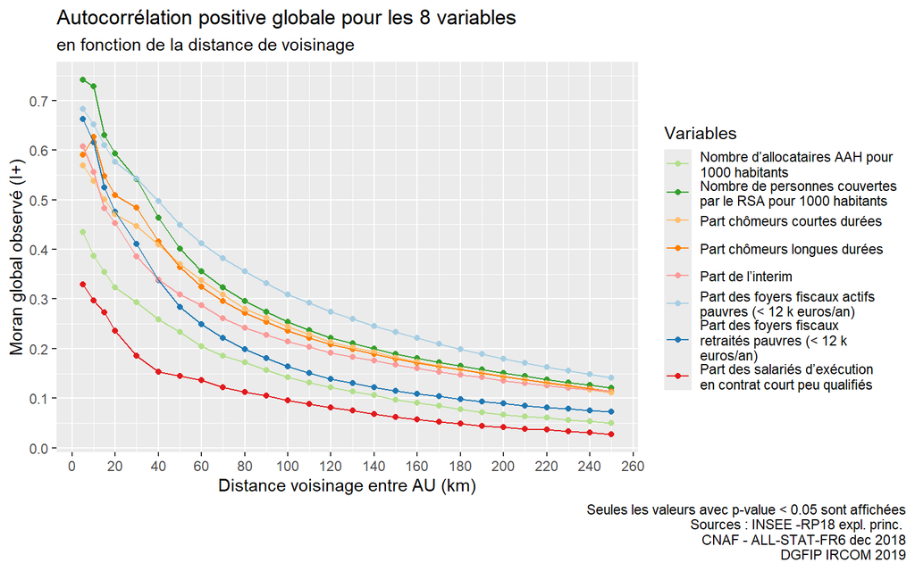

```r
# appliquer la fonction du global moran sur toutes les variables pour toutes les configurations de voisinages (long à calculer)


# moran_results <- calculate_moran_tests(df2 %>% select(where(is.numeric)), neighborhood_configs)

# Sauvegarde des résultats

 # write.csv(moran_results, "../Output/voisinagemoran_results.csv", row.names = FALSE)


# chargement des résultats
moran_results <- read.csv("../Output/voisinagemoran_results.csv")



### graphique pour les distances polygones

moran_polydist <- moran_results %>%
  # ne garder que les moran de l'autocorrélation positive pour les calculs de distances à la frontière de polygones
  filter(type == "I+" & config_type == "polygon" ) %>%
  mutate(Distance_km = as.numeric(param)/1000) %>%
  mutate(variable = factor(variable, levels = VarRelIntensite))

# ajout des labels de variables

moran_polydist <- moran_polydist %>%
  left_join(select(DicoVar, Variable, Label), by = c("variable" = "Variable")) %>%
  mutate(Label = recode(Label, "Part foyers retraités pauvres (< 12 k euros/an) sur l’ensemble des foyers fiscaux concernés par les retraites et pensions" = "Part des foyers fiscaux retraités pauvres (< 12 k euros/an)" ,
               "Part foyers traitements et salaires pauvres (< 12 k euros/an) sur l’ensemble des foyers fiscaux concernés par les traitements et salaires" =   "Part des foyers fiscaux actifs pauvres (< 12 k euros/an)" )) %>%
   mutate(Label = str_wrap(Label, width = 30))

# couleur
col <-  c("#33A02C" , "#B2DF8A","#1F78B4","#A6CEE3", "#FB9A99", "#E31A1C" ,"#FF7F00",  "#FDBF6F")
# vecteur couleur nommé
names(col) <- unique(moran_polydist$Label)

# graphique
g_moran_global_univ <- ggplot(moran_polydist %>%
         filter(pvalue < 0.05)) +
  geom_point(aes(x= Distance_km, y = observed, color = Label, group = Label )) +
  geom_line(aes(x= Distance_km, y = observed, color = Label, group = Label )) +
  scale_color_manual(values = col) +
  scale_x_continuous(breaks = scales::pretty_breaks(n = 10)) +
  scale_y_continuous(breaks = scales::pretty_breaks(n = 8)) +
  labs(title = "Autocorrélation positive globale pour les 8 variables",
       subtitle = "en fonction de la distance de voisinage",
       y = "Moran global observé (I+)",
       x = "Distance voisinage entre AU (km)",
       color = "Variables",
       caption = "Seules les valeurs avec p-value < 0.05 sont affichées\nSources : INSEE -RP18 expl. princ. \n CNAF - ALL-STAT-FR6 dec 2018\n DGFIP IRCOM 2019") +
  theme(plot.caption.position = "plot")

g_moran_global_univ
```

```r
  # ggsave(g_moran_global_univ + labs(title = "", subtitle = ""), path =  "../Output/", filename = "moranglobal_positif_dist_univ.png", device = "png",width = 200, height = 126, units = "mm")
```

Les niveaux d’auto-corrélation globale positive sont divers selon les variables, mais assez logiquement ces scores suivent une fonction décroissante en fonction de la distance de voisinage considérée.

Ici, pour les 8 variables, la pente est forte, ce qui suggère que le phénomène d’auto-corrélation positive (*est-ce qu’une AU ressemble à ses voisines ?*) s’exprime davantage à des faibles distances.

Sur la lecture de ce type de corrélogramme, on pourra voir [l’article de Sébastien Oliveau de 2004](https://shs.cairn.info/revue-espace-geographique-2010-1-page-51?lang=fr), cité en bibliographie de l’article.

# 3 Approches multivariées : typologie des AU selon les niveaux de précarité et effets de voisinage

Dans cette section on détaille l’appréhension multivariée de la précarité.

Le code produit la majorité des analyses présentées dans la section 3 de l’article, et fournit des figures complémentaires.

## 3.1 ACP

On réalise une ACP sur les huits variables. Cette analyse n’est pas guidée ici uniquement par une logique de statistiques exploratoires (on sait notamment que certaines variables sont fortement corrélées entre elles), mais par la volonté de produire un espace relatif dans lequel positionner l’ensemble des AU afin d’en faciliter la comparaison.

Le choix de conserver les 8 variables est donc davantage théorique : il s’agit de discuter notre appréhension de la précarité par selon les trois dimensions définies *a priori* dans l’article (Marges de la société salariale ; Pauvreté monétaire ; Marges du CDI) et leurs interactions.

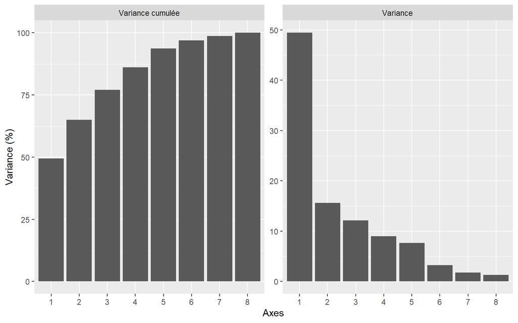

```r
## ACP

# tableau intermédiaire pour l'ACP
AU_typo <- df2 %>%
  left_join(select(au_info,AU2010, LIBAU2010, DEP )) %>%
  relocate(AU2010,LIBAU2010, DEP) %>%
  as.data.frame()



# garder les identifiants

rownames(AU_typo) <- paste(AU_typo$LIBAU2010,AU_typo$DEP, sep = "_" )

# faire l'ACP
res.pca <- PCA(AU_typo[,c(4:length(AU_typo))], # sans les id
               scale.unit = TRUE,
               # quali.sup = 1,
               # quanti.sup = 7, # employe_Inf
               graph = FALSE,
               ncp = 5) ### IMPORTANT LE NB DE COMPOSANTES UTILISEES par la suite

# pour une exploration interactive

  # explor(res.pca)

## Hiérarchisation des axes

eigenvalues <- as_tibble(res.pca$eig) %>%
  mutate(Axe = row_number()) %>%
  pivot_longer(-Axe, values_to = "Valeur", names_to = "Variable")

ggplot(eigenvalues %>%
         filter(! Variable == "eigenvalue") %>%
         filter(Axe < 9)) +
  geom_bar(aes(x = as.character(Axe) , y = Valeur),
           stat = "identity") +
  facet_wrap(~Variable,
             scales = "free_y",
             labeller = labeller(Variable = c(`cumulative percentage of variance` = "Variance cumulée",
                                              `percentage of variance` = "Variance"))) +
  labs(x = "Axes", y = "Variance (%)")
```

Choix de ne garder que les 5 premiers axes (effondrement de la variance pour le sixième axe).

## 3.2 Description des axes

Dans cette section, on trouve les matériaux complémentaires permettant la description complète des axes de l’ACP.

#### 3.2.0.1 Axe 1 vs 2

Représentation graphique des axes 1 et 2 sur le plan factoriel

```r
res <- explor::prepare_results(res.pca)

explor::PCA_var_plot(res, xax = 1, yax = 2, var_sup = FALSE, var_sup_choice = ,
                     var_lab_min_contrib = 0, col_var = NULL, labels_size = 10, scale_unit = TRUE,
                     transitions = TRUE, labels_positions = NULL)
```

[interactive chart not shown]

#### 3.2.0.2 Axe 3 vs 4

Représentation graphique des axes 3 et 4 sur le plan factoriel

```r
explor::PCA_var_plot(res, xax = 3, yax = 4, var_sup = FALSE, var_sup_choice = ,
                     var_lab_min_contrib = 0, col_var = NULL, labels_size = 10, scale_unit = TRUE,
                     transitions = TRUE, labels_positions = NULL)
```

[interactive chart not shown]

#### 3.2.0.3 Description de l’axe 1

```r
# AXe 1
df_temp <- res$vars %>%
  select(-all_of(c("Level", "Type", "Class"))) %>%
  filter(Axis == 1) %>%
  arrange(-Contrib) %>%
  left_join(select(DicoVar, Variable, Label), by = "Variable") %>%
  relocate(Variable,  Label)



DT::datatable(df_temp, class = 'cell-border stripe', rownames = F, filter = 'top', editable = F,
              caption = "AXE 1")
```

| Variable | Label | Axis | Coord | Contrib | Cos2 | Cor |
| --- | --- | --- | --- | --- | --- | --- |
| FOYFISC_PAUVRE_TS | Part foyers traitements et salaires pauvres (&lt; 12 k euros/an) sur l’ensemble des foyers fiscaux concernés par les traitements et salaires | 1 | 0.929 | 21.818 | 0.862 | 0.929 |
| CHOM_LONG | Part chômeurs longues durées | 1 | 0.904 | 20.655 | 0.816 | 0.904 |
| RSA_1khab | Nombre de personnes couvertes par le RSA pour 1000 habitants | 1 | 0.895 | 20.273 | 0.801 | 0.895 |
| FOYFISC_PAUVRE_RP | Part foyers retraités pauvres (&lt; 12 k euros/an) sur l’ensemble des foyers fiscaux concernés par les retraites et pensions | 1 | 0.828 | 17.334 | 0.685 | 0.828 |
| CHOM_COURT | Part chômeurs courtes durées | 1 | 0.712 | 12.815 | 0.506 | 0.712 |
| AAH_1khab | Nombre d’allocataires AAH pour 1000 habitants | 1 | 0.472 | 5.63 | 0.223 | 0.472 |
| INTERIM | Part de l’interim | 1 | -0.192 | 0.928 | 0.037 | -0.192 |
| EMPL_INF_PEUQUAL_CDD | Part des salariés d’exécution en contrat court peu qualifiés | 1 | 0.147 | 0.547 | 0.022 | 0.147 |

Commentaire : axe marqué par un cumul des marqueurs de précarité témoignant de l’éloignement à l’emploi, en particulier pour les dimensions pauvreté monétaire et marges de la société salariale

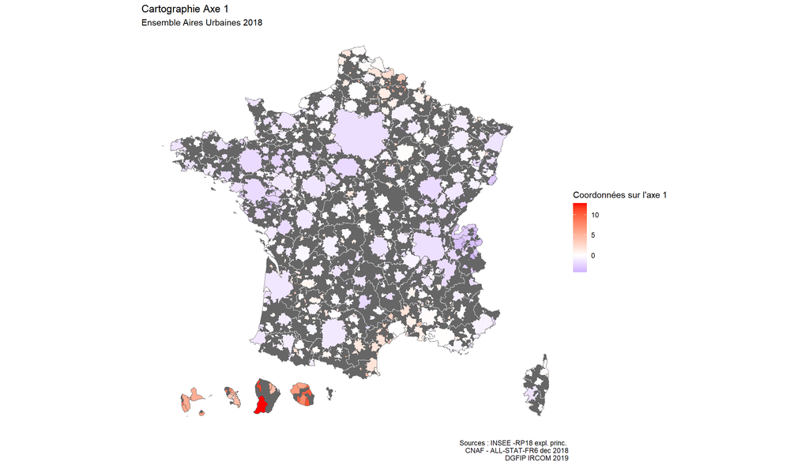

```r
AU_cartoAxe <- AU_typo %>%
  bind_cols(., res.pca$ind$coord)


## ajout des géometries AU
AU_cartoAxe <- AU_cartoAxe %>%
  left_join(AUsf) %>% st_sf


ggplot() +
  geom_sf(data =depsf, fill = "grey40", color = "white", size = 0.5) +
  geom_sf(data = AU_cartoAxe,
          mapping = aes(fill = Dim.1 ), size = 0.25) +
  scale_fill_gradient2(low = "blue", high = "red", mid = "white", midpoint = 0,na.value = NA) +
  theme_void() +
  labs(title = "Cartographie Axe 1",
       subtitle = "Ensemble Aires Urbaines 2018",
       fill = "Coordonnées sur l'axe 1",
       caption = "Sources : INSEE -RP18 expl. princ. \n CNAF - ALL-STAT-FR6 dec 2018\n DGFIP IRCOM 2019")
```

#### 3.2.0.4 Description de l’axe 2

```r
# Axe 2
df_temp <- res$vars %>%
  select(-all_of(c("Level", "Type", "Class"))) %>%
  filter(Axis == 2) %>%
  arrange(-Contrib) %>%
  left_join(select(DicoVar, Variable, Label), by = "Variable") %>%
  relocate(Variable,  Label)



DT::datatable(df_temp, class = 'cell-border stripe', rownames = F, filter = 'top', editable = F,
              caption = "AXE 2")
```

| Variable | Label | Axis | Coord | Contrib | Cos2 | Cor |
| --- | --- | --- | --- | --- | --- | --- |
| EMPL_INF_PEUQUAL_CDD | Part des salariés d’exécution en contrat court peu qualifiés | 2 | 0.809 | 52.453 | 0.654 | 0.809 |
| INTERIM | Part de l’interim | 2 | 0.748 | 44.919 | 0.56 | 0.748 |
| CHOM_COURT | Part chômeurs courtes durées | 2 | 0.102 | 0.831 | 0.01 | 0.102 |
| CHOM_LONG | Part chômeurs longues durées | 2 | -0.083 | 0.548 | 0.007 | -0.083 |
| AAH_1khab | Nombre d’allocataires AAH pour 1000 habitants | 2 | 0.079 | 0.5 | 0.006 | 0.079 |
| FOYFISC_PAUVRE_TS | Part foyers traitements et salaires pauvres (&lt; 12 k euros/an) sur l’ensemble des foyers fiscaux concernés par les traitements et salaires | 2 | 0.07 | 0.392 | 0.005 | 0.07 |
| RSA_1khab | Nombre de personnes couvertes par le RSA pour 1000 habitants | 2 | -0.062 | 0.311 | 0.004 | -0.062 |
| FOYFISC_PAUVRE_RP | Part foyers retraités pauvres (&lt; 12 k euros/an) sur l’ensemble des foyers fiscaux concernés par les retraites et pensions | 2 | -0.024 | 0.046 | 0.001 | -0.024 |

Commentaire : poids des formes d’emplois d’exécution et éloignés du CDI (contrat court et interim)

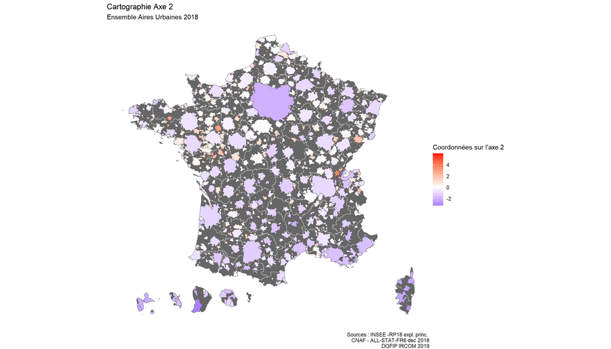

```r
ggplot() +
  geom_sf(data =depsf, fill = "grey40", color = "white", size = 0.5) +
  geom_sf(data = AU_cartoAxe,
          mapping = aes(fill = Dim.2 ), size = 0.25) +
  scale_fill_gradient2(low = "blue", high = "red", mid = "white", midpoint = 0,na.value = NA) +
  theme_void() +
  labs(title = "Cartographie Axe 2",
       subtitle = "Ensemble Aires Urbaines 2018",
       fill = "Coordonnées sur l'axe 2",
       caption = "Sources : INSEE -RP18 expl. princ. \n CNAF - ALL-STAT-FR6 dec 2018\n DGFIP IRCOM 2019")
```

#### 3.2.0.5 Description de l’axe 3

```r
# AXe 3
df_temp <- res$vars %>%
  select(-all_of(c("Level", "Type", "Class"))) %>%
  filter(Axis == 3) %>%
  arrange(-Contrib) %>%
  left_join(select(DicoVar, Variable, Label), by = "Variable") %>%
  relocate(Variable,  Label)



DT::datatable(df_temp, class = 'cell-border stripe', rownames = F, filter = 'top', editable = F,
              caption = "AXE 3")
```

| Variable | Label | Axis | Coord | Contrib | Cos2 | Cor |
| --- | --- | --- | --- | --- | --- | --- |
| AAH_1khab | Nombre d’allocataires AAH pour 1000 habitants | 3 | 0.77 | 61.289 | 0.593 | 0.77 |
| INTERIM | Part de l’interim | 3 | -0.316 | 10.345 | 0.1 | -0.316 |
| CHOM_COURT | Part chômeurs courtes durées | 3 | -0.29 | 8.683 | 0.084 | -0.29 |
| CHOM_LONG | Part chômeurs longues durées | 3 | -0.271 | 7.58 | 0.073 | -0.271 |
| RSA_1khab | Nombre de personnes couvertes par le RSA pour 1000 habitants | 3 | -0.225 | 5.215 | 0.05 | -0.225 |
| EMPL_INF_PEUQUAL_CDD | Part des salariés d’exécution en contrat court peu qualifiés | 3 | 0.199 | 4.084 | 0.04 | 0.199 |
| FOYFISC_PAUVRE_TS | Part foyers traitements et salaires pauvres (&lt; 12 k euros/an) sur l’ensemble des foyers fiscaux concernés par les traitements et salaires | 3 | 0.146 | 2.19 | 0.021 | 0.146 |
| FOYFISC_PAUVRE_RP | Part foyers retraités pauvres (&lt; 12 k euros/an) sur l’ensemble des foyers fiscaux concernés par les retraites et pensions | 3 | 0.077 | 0.613 | 0.006 | 0.077 |

Commentaire : axe fortement marqué par la variable de nombre d’allocataires de l’AAH pour 1000 habitants. La géographie de cette variable et, en générale, de l’AAH (notamment les différences institutionnelles entre départements), nécessiteraient une enquête à part entière.

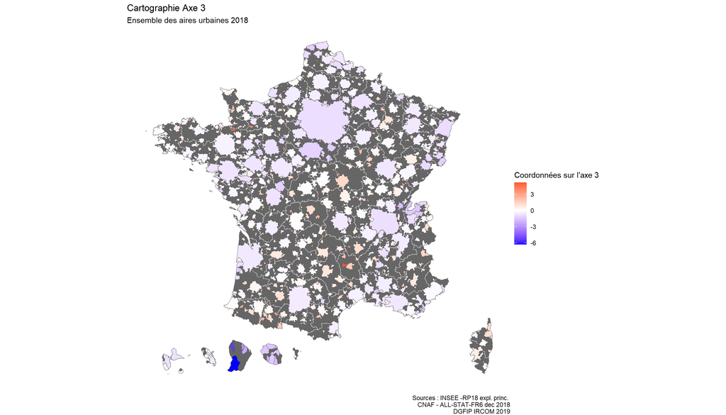

```r
ggplot() +
  geom_sf(data =depsf, fill = "grey40", color = "white", size = 0.5) +
  geom_sf(data = AU_cartoAxe,
          mapping = aes(fill = Dim.3 ), size = 0.25) +
  scale_fill_gradient2(low = "blue", high = "red", mid = "white", midpoint = 0,na.value = NA) +
  theme_void() +
  labs(title = "Cartographie Axe 3",
       subtitle = "Ensemble des aires urbaines 2018",
       fill = "Coordonnées sur l'axe 3",
       caption = "Sources : INSEE -RP18 expl. princ. \n CNAF - ALL-STAT-FR6 dec 2018\n DGFIP IRCOM 2019")
```

#### 3.2.0.6 Description de l’axe 4

```r
# AXe 4
df_temp <- res$vars %>%
  select(-all_of(c("Level", "Type", "Class"))) %>%
  filter(Axis == 4) %>%
  arrange(-Contrib) %>%
  left_join(select(DicoVar, Variable, Label), by = "Variable") %>%
  relocate(Variable,  Label)



DT::datatable(df_temp, class = 'cell-border stripe', rownames = F, filter = 'top', editable = F,
              caption = "AXE 4")
```

| Variable | Label | Axis | Coord | Contrib | Cos2 | Cor |
| --- | --- | --- | --- | --- | --- | --- |
| INTERIM | Part de l’interim | 4 | 0.534 | 39.7 | 0.286 | 0.534 |
| EMPL_INF_PEUQUAL_CDD | Part des salariés d’exécution en contrat court peu qualifiés | 4 | -0.524 | 38.153 | 0.275 | -0.524 |
| AAH_1khab | Nombre d’allocataires AAH pour 1000 habitants | 4 | 0.386 | 20.736 | 0.149 | 0.386 |
| FOYFISC_PAUVRE_RP | Part foyers retraités pauvres (&lt; 12 k euros/an) sur l’ensemble des foyers fiscaux concernés par les retraites et pensions | 4 | -0.074 | 0.761 | 0.005 | -0.074 |
| RSA_1khab | Nombre de personnes couvertes par le RSA pour 1000 habitants | 4 | 0.058 | 0.464 | 0.003 | 0.058 |
| CHOM_LONG | Part chômeurs longues durées | 4 | 0.031 | 0.135 | 0.001 | 0.031 |
| CHOM_COURT | Part chômeurs courtes durées | 4 | -0.016 | 0.034 | 0 | -0.016 |
| FOYFISC_PAUVRE_TS | Part foyers traitements et salaires pauvres (&lt; 12 k euros/an) sur l’ensemble des foyers fiscaux concernés par les traitements et salaires | 4 | -0.011 | 0.017 | 0 | -0.011 |

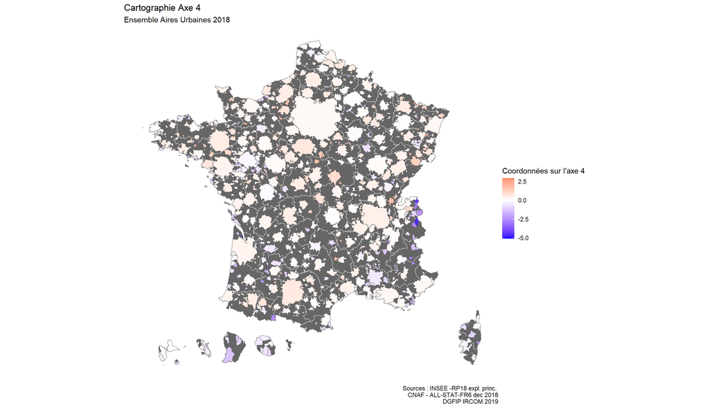

```r
ggplot() +
  geom_sf(data =depsf, fill = "grey40", color = "white", size = 0.5) +
  geom_sf(data = AU_cartoAxe,
          mapping = aes(fill = Dim.4 ), size = 0.25) +
  scale_fill_gradient2(low = "blue", high = "red", mid = "white", midpoint = 0,na.value = NA) +
  theme_void() +
  labs(title = "Cartographie Axe 4",
       subtitle = "Ensemble Aires Urbaines 2018",
       fill = "Coordonnées sur l'axe 4",
       caption = "Sources : INSEE -RP18 expl. princ. \n CNAF - ALL-STAT-FR6 dec 2018\n DGFIP IRCOM 2019")
```

#### 3.2.0.7 Description de l’axe 5

```r
# AXe 5
df_temp <- res$vars %>%
  select(-all_of(c("Level", "Type", "Class"))) %>%
  filter(Axis == 5) %>%
  arrange(-Contrib) %>%
  left_join(select(DicoVar, Variable, Label), by = "Variable") %>%
  relocate(Variable,  Label)



DT::datatable(df_temp, class = 'cell-border stripe', rownames = F, filter = 'top', editable = F,
              caption = "AXE 5")
```

| Variable | Label | Axis | Coord | Contrib | Cos2 | Cor |
| --- | --- | --- | --- | --- | --- | --- |
| CHOM_COURT | Part chômeurs courtes durées | 5 | -0.602 | 58.988 | 0.363 | -0.602 |
| FOYFISC_PAUVRE_RP | Part foyers retraités pauvres (&lt; 12 k euros/an) sur l’ensemble des foyers fiscaux concernés par les retraites et pensions | 5 | 0.411 | 27.49 | 0.169 | 0.411 |
| RSA_1khab | Nombre de personnes couvertes par le RSA pour 1000 habitants | 5 | 0.184 | 5.485 | 0.034 | 0.184 |
| INTERIM | Part de l’interim | 5 | 0.118 | 2.269 | 0.014 | 0.118 |
| AAH_1khab | Nombre d’allocataires AAH pour 1000 habitants | 5 | -0.116 | 2.179 | 0.013 | -0.116 |
| CHOM_LONG | Part chômeurs longues durées | 5 | 0.104 | 1.754 | 0.011 | 0.104 |
| FOYFISC_PAUVRE_TS | Part foyers traitements et salaires pauvres (&lt; 12 k euros/an) sur l’ensemble des foyers fiscaux concernés par les traitements et salaires | 5 | -0.104 | 1.744 | 0.011 | -0.104 |
| EMPL_INF_PEUQUAL_CDD | Part des salariés d’exécution en contrat court peu qualifiés | 5 | 0.024 | 0.091 | 0.001 | 0.024 |

Commentaire : axe marqué par une opposition entre la part des chômeurs courte durée (-) et la part des foyers retraités pauvres (+).

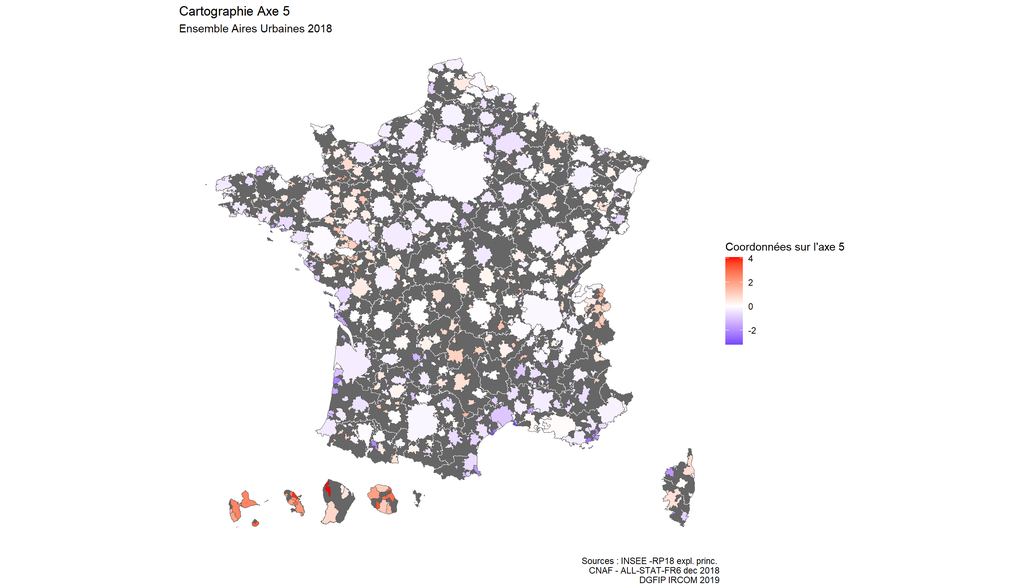

```r
ggplot() +
  geom_sf(data =depsf, fill = "grey40", color = "white", size = 0.5) +
  geom_sf(data = AU_cartoAxe,
          mapping = aes(fill = Dim.5 ), size = 0.25) +
  scale_fill_gradient2(low = "blue", high = "red", mid = "white", midpoint = 0,na.value = NA) +
  theme_void() +
  labs(title = "Cartographie Axe 5",
       subtitle = "Ensemble Aires Urbaines 2018",
       fill = "Coordonnées sur l'axe 5",
       caption = "Sources : INSEE -RP18 expl. princ. \n CNAF - ALL-STAT-FR6 dec 2018\n DGFIP IRCOM 2019")
```

## 3.3 Auto-corrélation spatiale multivariée

Sélection du voisinage métriques et des axes de l’ACP. Ces résultats sont présentés dans la section 3.2 de l’article.

### 3.3.1 Auto-corrélation spatiale globale sur les axes de l’ACP

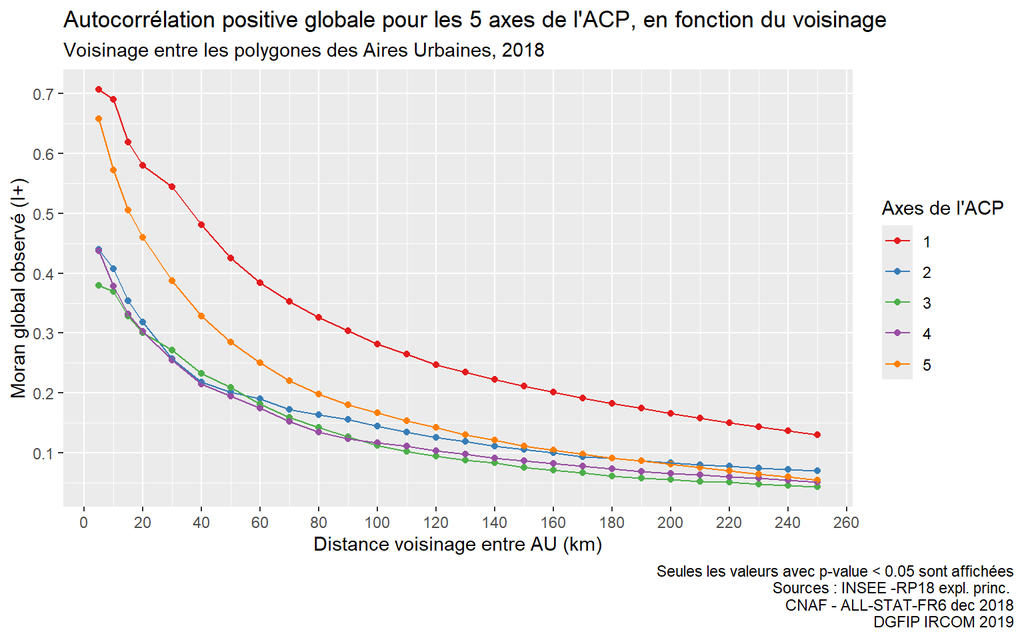

```r
# moran global (avec la même fonction que la partie univariée)

# axes de l'acp

data <- res.pca$ind$coord %>% as.data.frame()

# calcul des morans (on peut filtrer pour ne pas mettre toutes les config de voisinage)
# moran_acp_results <- calculate_moran_tests(data, neighborhood_configs)


# Sauvegarde des résultats

 # write.csv(moran_acp_results, "../Output/voisinagemoran_acp_results.csv", row.names = FALSE)

# ouverture des résultats
moran_acp_results <- read.csv("../Output/voisinagemoran_acp_results.csv")


### graphique pour les distances polygones


moran_polydist_acp <- moran_acp_results %>%
  # ne garder que les moran de l'autocorrélation positive pour les calculs de distances à la frontière de polygones
  filter(type == "I+" & config_type == "polygon" ) %>%
  mutate(Distance_km = as.numeric(param)/1000) %>%
  mutate(variable = as.character(parse_number(variable)*10))



g_moran_global_acp <- ggplot(moran_polydist_acp %>%
         filter(pvalue < 0.05)) +
  geom_point(aes(x= Distance_km, y = observed, color = variable, group = variable )) +
  geom_line(aes(x= Distance_km, y = observed, color = variable, group = variable )) +
  scale_color_brewer(palette =  "Set1") +
  scale_x_continuous(breaks = scales::pretty_breaks(n = 10)) +
  scale_y_continuous(breaks = scales::pretty_breaks(n = 8)) +
  labs(title = "Autocorrélation positive globale pour les 5 axes de l'ACP, en fonction du voisinage",
       subtitle = "Voisinage entre les polygones des Aires Urbaines, 2018",
       y = "Moran global observé (I+)", x = "Distance voisinage entre AU (km)",
       caption = "Seules les valeurs avec p-value < 0.05 sont affichées\nSources : INSEE -RP18 expl. princ. \n CNAF - ALL-STAT-FR6 dec 2018\n DGFIP IRCOM 2019",
       color = "Axes de l'ACP") +
  theme(plot.caption.position = "plot")

g_moran_global_acp
```

```r
  # ggsave(g, path =  "../Output/", filename = "moran_positif_global_ACP.png", device = "png",width = 200, height = 126, units = "mm")
```

### 3.3.2 Auto-corrélation spatiale locale sur les axes 1 & 2 de l’ACP

#### 3.3.2.1 Comparaison axe 1 et axe 2

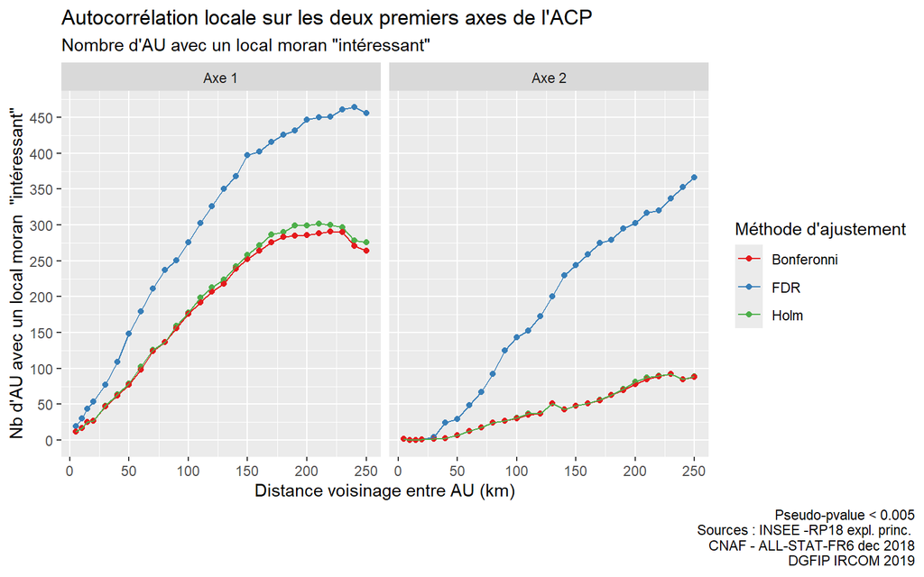

```r
# selection des axes
var_names <- c("Dim.1", "Dim.2")

# selection des configurations de voisinages (uniquement polygones)

neighborhood_configs_local <- names(neighborhood_configs) %>%
      str_detect('polygon') %>%
      keep(neighborhood_configs, .)

## calcul des morans locaux et résumé stats (long à calculer)
# localmoran_results <- analyze_local_moran(data = data,
#                                var_names = var_names,
#                                listw_configs = neighborhood_configs_local,
#                                seuil = 0.005)
#
#
# # sauvegarde et ouverture
# saveRDS(localmoran_results, "../Output/localmoran_summary.rds")

# chargement des résultats
localmoran_results <- readRDS("../Output/localmoran_summary.rds")

## format long

df <- localmoran_results$summary %>%
  mutate(voisinage_km = as.numeric(voisinage_km)) %>%
  pivot_longer(cols = starts_with("sig"), names_to = "pvalue_method", values_to = "n_significatifs") %>%
  pivot_longer(cols = c(`High-High`, `Low-Low`, `Low-High`, `High-Low`), names_to = "Type_quadrant", values_to = "fdr_count") %>%
  mutate(variable = str_replace(variable, "Dim.", "Axe "))



# graphique nombre de LM siginificatifs

g1 <-  ggplot(df) +
  geom_point(aes(x= voisinage_km, y =n_significatifs, color = pvalue_method, group = pvalue_method )) +
  geom_line(aes(x= voisinage_km, y =n_significatifs, color = pvalue_method, group = pvalue_method )) +
  scale_color_manual("Méthode d'ajustement",
                     values = brewer.pal(3,"Set1"),
                     labels = c("Bonferonni", "FDR", "Holm")) +
  scale_x_continuous(breaks = scales::pretty_breaks(n = 6)) +
  scale_y_continuous(breaks = scales::pretty_breaks(n = 8)) +
    facet_wrap(~variable) +
  labs(title = "Autocorrélation locale sur les deux premiers axes de l'ACP",
       subtitle = "Nombre d'AU avec un local moran \"intéressant\"",
       y = "Nb d'AU avec un local moran  \"intéressant\"", x = "Distance voisinage entre AU (km)",
       caption = "Pseudo-pvalue < 0.005\nSources : INSEE -RP18 expl. princ. \n CNAF - ALL-STAT-FR6 dec 2018\n DGFIP IRCOM 2019") +
  theme(plot.caption.position = "plot")

g1
```

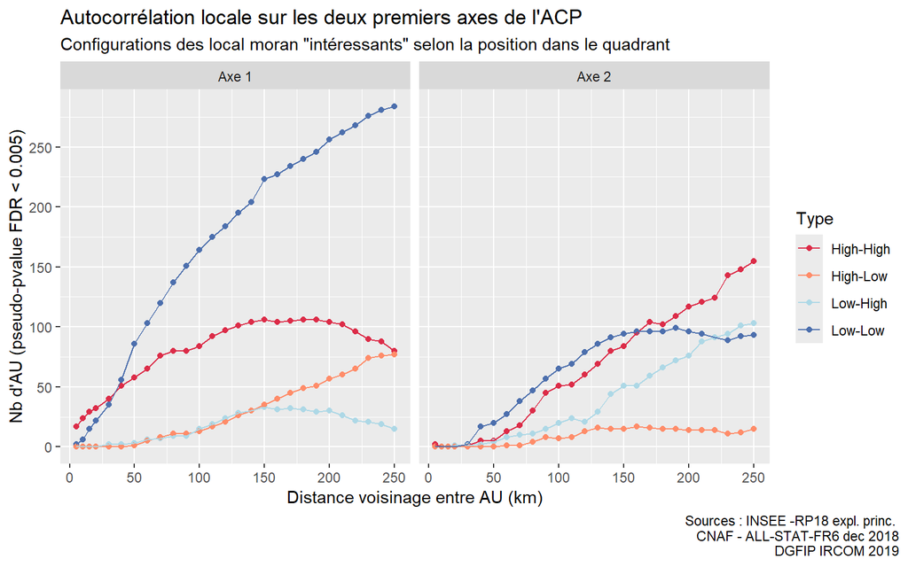

```r
   # ggsave(g1, path =  "../Output/", filename = "lmoran_ax1_2_signif.png", device = "png",width = 200, height = 126, units = "mm")



  # graphique nombre nb type d'autocorrélation quadrant

g2 <-  ggplot(df) +
  geom_point(aes(x= voisinage_km, y =fdr_count, color = Type_quadrant, group = Type_quadrant )) +
  geom_line(aes(x= voisinage_km, y =fdr_count, color = Type_quadrant, group = Type_quadrant )) +
  scale_color_manual("Type",
                     values = c("#DC2C48" ,"salmon1" , "lightblue","#4C6FAD")) +
  scale_x_continuous(breaks = scales::pretty_breaks(n = 8)) +
  scale_y_continuous(breaks = scales::pretty_breaks(n = 8)) +
    facet_wrap(~variable) +
  labs(title = "Autocorrélation locale sur les deux premiers axes de l'ACP",
       subtitle = "Configurations des local moran \"intéressants\" selon la position dans le quadrant",
       y = "Nb d'AU (pseudo-pvalue FDR < 0.005)", x = "Distance voisinage entre AU (km)",
       caption = "Sources : INSEE -RP18 expl. princ. \n CNAF - ALL-STAT-FR6 dec 2018\n DGFIP IRCOM 2019") +
  theme(plot.caption.position = "plot")
g2
```

```r
 # ggsave(g2, path =  "../Output/", filename = "lmoran_ax1_2_quadrant_count.png", device = "png",width = 200, height = 126, units = "mm")
```

#### 3.3.2.2 Graphiques pour l’axe 1 seulement

Pour l’article, on présente uniquement les résultats pour l’axe 1.

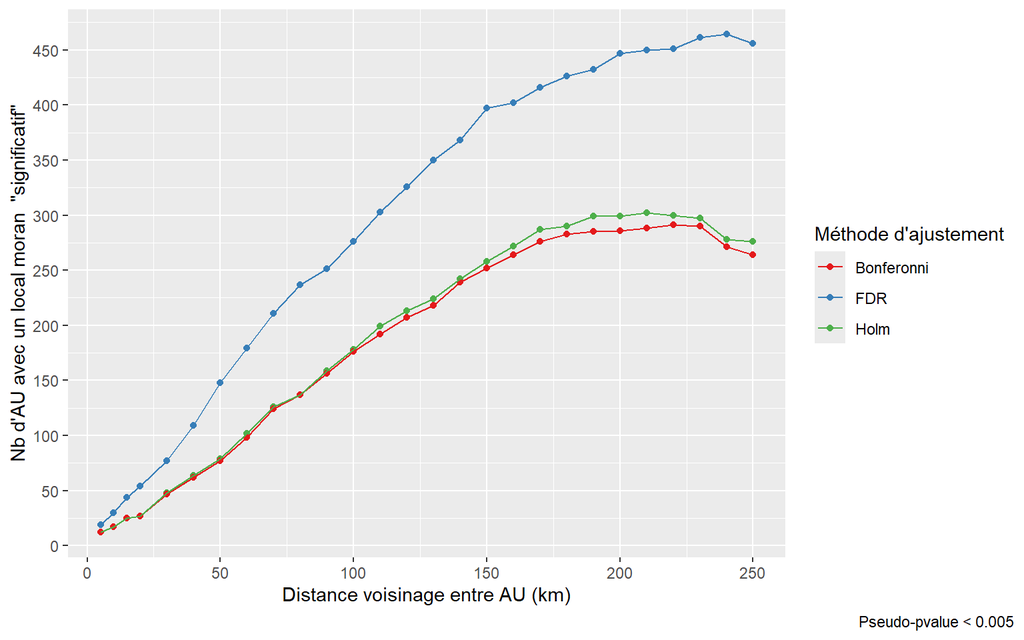

```r
## figures  pour l'axe 1 uniquement

g1 <-  ggplot(df %>% filter(variable == "Axe 1")) +
  geom_point(aes(x= voisinage_km, y =n_significatifs, color = pvalue_method, group = pvalue_method )) +
  geom_line(aes(x= voisinage_km, y =n_significatifs, color = pvalue_method, group = pvalue_method )) +
  scale_color_manual("Méthode d'ajustement",
                     values = brewer.pal(3,"Set1"),
                     labels = c("Bonferonni", "FDR", "Holm")) +
  scale_x_continuous(breaks = scales::pretty_breaks(n = 6)) +
  scale_y_continuous(breaks = scales::pretty_breaks(n = 8)) +
  labs(y = "Nb d'AU avec un local moran  \"significatif\"", x = "Distance voisinage entre AU (km)",
       caption = "Pseudo-pvalue < 0.005") +
  theme(plot.caption.position = "plot")

g1
```

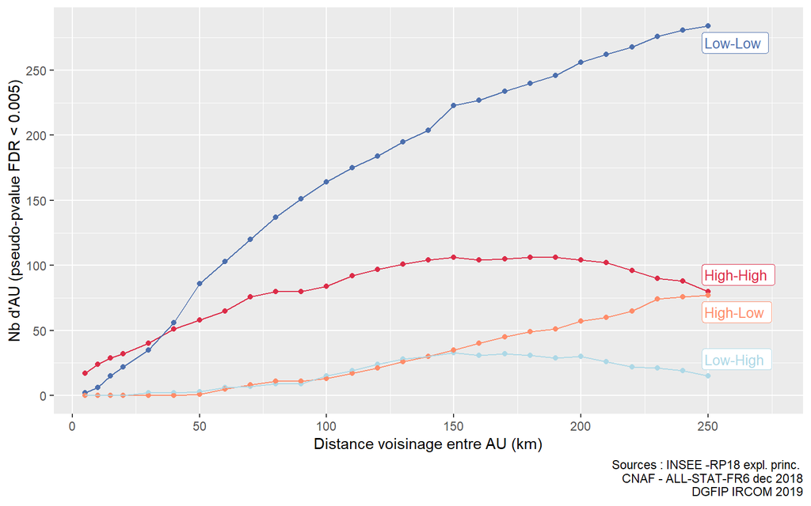

```r
  # graphique nombre nb type d'autocorrélation quadrant

g2 <- ggplot(df %>% filter(variable == "Axe 1")) +
  geom_point(aes(x = voisinage_km, y = fdr_count, color = Type_quadrant, group = Type_quadrant)) +
  geom_line(aes(x = voisinage_km, y = fdr_count, color = Type_quadrant, group = Type_quadrant)) +
  geom_label_repel(
    data = df %>%
      filter(variable == "Axe 1") %>%
      group_by(Type_quadrant) %>%
      filter(voisinage_km == max(voisinage_km)) %>%  # Utiliser filter au lieu de slice_max
      slice(1),  # Prendre seulement la première ligne si plusieurs valeurs max identiques
    aes(x = voisinage_km, y = fdr_count, label = Type_quadrant, color = Type_quadrant),
    hjust = 0,
    nudge_x = 0.5,
    direction = "y",
    segment.size = 0.2,
    size = 3.5,
    show.legend = FALSE
  ) +
  scale_color_manual(values = c("#DC2C48", "salmon1", "lightblue", "#4C6FAD")) +
  scale_x_continuous(breaks = scales::pretty_breaks(n = 8), expand = expansion(mult = c(0.05, 0.15))) +
  scale_y_continuous(breaks = scales::pretty_breaks(n = 8)) +
  labs(y = "Nb d'AU (pseudo-pvalue FDR < 0.005)",
       x = "Distance voisinage entre AU (km)",
       caption = "Sources : INSEE -RP18 expl. princ. \n CNAF - ALL-STAT-FR6 dec 2018\n DGFIP IRCOM 2019") +
  theme(plot.caption.position = "plot",
        legend.position = "none")
g2
```

```r
 # ggsave(g2, path =  "../Output/", filename = "moranlocal_quadrant_dist.png", device = "png",width = 200, height = 126, units = "mm")
```